# **Trabalho Prático de Extração de Conhecimento de Dados Biológicos**

Carlos Gomes (PG51681), Laís Carvalho (PG52536), Rita Nóbrega (PG46733)

2024-05-06

# 1 **Contextualização**

O conjunto de dados selecionados para este trabalho foram retirados de um estudo cohort com 672 amostras recolhidas através de biopsias a 562 pacientes com Leucemia Mielóide Aguda (LMA)[^1]. Com o objetivo de correlacionar a sensibilidade e resistência de grupos de pacientes com LMA a tratamentos já existentes com a ocorrência de mutações, foram realizadas anotações clínicas detalhadas, estudos genómicos e transcriptómicos (com a sequenciação do exoma (622 amostras) e do RNA (451 amostras)), assim como testes *ex vivo* de sensibilidade a compostos. Os dados e estudo original podem ser consultados através do Genomic Data Commons (GDC)[^2].

Este trabalho tem como objetivo analisar os dados de expressão de pacientes com AML, comparando os seus dados transcriptómicos de acordo com o sexo, tipo de amostra e tratamentos cumulativos dados aos pacientes, com vista a obter informações sobre genes possivelmente expressos diferencialmente e/ou enriquecidos, que tenham um papel importante no tratamento da doença e na sobrevivência dos pacientes.

# 2 **Datasets**

## 2.1 *Transferência e leitura dos datastes*

Depois de importar as bibliotecas necessárias, começamos por **associar** os datasets presentes no repositório online [^3] a uma **variável**.

```r
RNA_cpm = read.table("Dados/data_mrna_seq_cpm.txt", header = T, sep = '\t')

data_patient = read.table("Dados/data_clinical_patient.txt", header = T, sep = '\t')

data_sample = read_tsv("Dados/data_clinical_sample.txt", na = "", show_col_types = FALSE)

data_mutations = read.table("Dados/data_mutations.txt", header = T, sep = '\t')
```

## 2.2 *Pré-processamento dos dados*

### 2.2.1 RNA_cpm

Os nossos dados de transcriptómica já se encontram normalizados através do método Trimmed Mean of M caling (TMM) que serve para corrigir diferenças sistemáticas na composição das bibliotecas de RNA entre amostras (sendo uma normalização do tamanho da biblioteca e não dos dados em si), ajudando a reduzir a variabilidade técnica entre amostras. Após esta normalização TMM, as contagens foram convertidos para CPM (Counts per million), uma medida comum em análise de expressão génica que normaliza as contagens tendo em consideração as diferenças na profundidade de sequenciação entre as amostras.

Começámos por verificar alguns aspetos relativamente ao dataset para perceber que tipo de preparação/tratamento os dados necessitavam.

```r
class(RNA_cpm)
```

```
## [1] "data.frame"
```

```r
head(unlist(lapply(RNA_cpm,class)) )
```

```
##            Hugo_Symbol         Entrez_Gene_Id aml_ohsu_2018_12.00023
##            "character"              "logical"              "numeric"
## aml_ohsu_2018_12.00051 aml_ohsu_2018_12.00066 aml_ohsu_2018_12.00150
##              "numeric"              "numeric"              "numeric"
```

```r
dim(RNA_cpm)
```

```
## [1] 22843   453
```

```r
head(colnames(RNA_cpm))
```

```
## [1] "Hugo_Symbol"            "Entrez_Gene_Id"         "aml_ohsu_2018_12.00023"
## [4] "aml_ohsu_2018_12.00051" "aml_ohsu_2018_12.00066" "aml_ohsu_2018_12.00150"
```

```r
head(rownames(RNA_cpm))
```

```
## [1] "1" "2" "3" "4" "5" "6"
```

Com o código acima é possível perceber:

- **class(RNA_cpm)** -> Classe do dataset, dataframe neste caso;
- **unlist(lapply(RNA_cpm,class))** -> Classe de cada coluna do dataframe
- **dim(RNA_cpm)** -> Dimensão do dataframe;
- **colnames(RNA_cpm)** e **head(rownames(RNA_cpm))** -> Verificar se o nome dos genes se está associado às linhas, e o nome das amostras às colunas.

Quando tentámos associar o nome dos genes à coluna, reparámos que devido há existência de genes duplicados não o conseguimos fazer. Assim, procedemos à verificação destes duplicados.

```r
which(duplicated(RNA_cpm[,1]))
```

```
## [1] 13532 13695 15321 15913 18161 20095
```

```r
RNA_cpm[which(duplicated(RNA_cpm[,1])),1]
```

```
## [1] "BTBD8"  "COMMD9" "S1PR3"  "MYO18A" "ENO1"   "MACF1"
```

```r
which(RNA_cpm == 'BTBD8', arr.ind = T)
```

```
##        row col
## [1,]   976   1
## [2,] 13532   1
```

```r
RNA_cpm[which(duplicated(RNA_cpm[,1])),1] = paste(RNA_cpm[which(duplicated(RNA_cpm[,1])),1], "_duplicado", sep = "")

which(duplicated(RNA_cpm[,1]))
```

```
## integer(0)
```

```r
RNA_cpm[13532, 1]
```

```
## [1] "BTBD8_duplicado"
```

O código utilizado serviu para:

- **(which(duplicated(RNA_cpm[,1])))** -> Saber quantos genes têm o nome repetido (6 nomes duplicados neste caso);
- **RNA_cpm[which(duplicated(RNA_cpm[,1])),1]** -> Obter o nome dos genes duplicados;
- **which(RNA_cpm == ‘BTBD8’, arr.ind = T)** -> Confirmar se o nome está duplicado;

Nesta fase, e através de verificação manual, percebemos que o nome é de facto igual, no entanto os valores associados são diferentes.

Optamos então por adicionar “_duplicado” para os distinguir.

- **RNA_cpm[which(duplicated(RNA_cpm[,1])),1] = paste(RNA_cpm[which(duplicated(RNA_cpm[,1])),1], “_duplicado”, sep = ““)** -> Adiciona o”duplicado”;
- **which(duplicated(RNA_cpm[,1]))** -> Retorna as posições das linhas duplicadas da primeira coluna;
- **RNA_cpm[13532, 1]** -> Retorna o valor na linha 13532 e coluna 1.

Assim, já é possível associar o nome dos genes às linhas, corretamente:

```r
rownames(RNA_cpm) = RNA_cpm[, 1]

head(rownames(RNA_cpm))
```

```
## [1] "TSPAN6"   "DPM1"     "SCYL3"    "C1orf112" "FGR"      "CFH"
```

- **rownames(RNA_cpm) = RNA_cpm[, 1]** -> Transformar os valores da primeira coluna, no nome das linhas;
- **head(rownames(RNA_cpm))** -> para Verificar se não ocorreu nenhum erro no comando anterior e que o nome dos genes está associado às linhas;

De seguida, continuamos com o pré-processamento dos dados, verificando se existem valores omissos.

```r
any(is.na(RNA_cpm))
```

```
## [1] TRUE
```

```r
RNA_cpm$Entrez_Gene_Id <- NULL

any(is.na(RNA_cpm))
```

```
## [1] FALSE
```

- **any(is.na(RNA_cpm))** -> Ver se há missing values
- **RNA_cpm$Entrez_Gene_Id <- NULL** -> Eliminar a coluna com missing values
- **any(is.na(RNA_cpm))** -> Verificar outra vez se há missing values

Os valores omissos que existiam no dataframe estavam todos presentes na mesma coluna (’Entrez_Gene_Id”), por isso depois da sua eliminação, já não existem NAs.

### 2.2.2 Metadados

#### 2.2.2.1 data_sample

Começámos por verificar alguns aspetos relativos ao dataset:

```r
class(data_sample)
```

```
## [1] "spec_tbl_df" "tbl_df"      "tbl"         "data.frame"
```

```r
data_sample = as.data.frame(data_sample)

class(data_sample)
```

```
## [1] "data.frame"
```

```r
data_sample = data_sample[-c(1:3),]

colnames(data_sample) = data_sample[1,]

data_sample = data_sample[-1,]

str(data_sample)
```

```
## 'data.frame':    672 obs. of  75 variables:
##  $ PATIENT_ID                                      : chr  "aml_ohsu_2018_163" "aml_ohsu_2018_174" "aml_ohsu_2018_175" "aml_ohsu_2018_45" ...
##  $ SAMPLE_ID                                       : chr  "aml_ohsu_2018_09-00705" "aml_ohsu_2018_10-00136" "aml_ohsu_2018_10-00172" "aml_ohsu_2018_10-00507" ...
##  $ SAMPLE_TIMEPOINT                                : chr  "Denovo" "Denovo" "Denovo" "Denovo" ...
##  $ FUSION                                          : chr  "None" "None" "None" "None" ...
##  $ SPECIFIC_DIAGNOSIS_AT_INCLUSION                 : chr  "AML with mutated NPM1" "Acute myelomonocytic leukaemia" "Acute myelomonocytic leukaemia" "AML with mutated NPM1" ...
##  $ ELN_2017                                        : chr  "Favorable or Intermediate" "Adverse" "Intermediate or Adverse" "Favorable or Intermediate" ...
##  $ ELN_2008                                        : chr  "Intermediate-I" "Intermediate-II" "Intermediate-II" "Intermediate-I" ...
##  $ SPECIFIC_DIAGNOSIS_AT_ACQUISITION               : chr  "AML with mutated NPM1" "Acute myelomonocytic leukaemia" "Acute myelomonocytic leukaemia" "AML with mutated NPM1" ...
##  $ GROUP                                           : chr  "Initial Acute Leukemia Diagnosis" "Initial Acute Leukemia Diagnosis" "Initial Acute Leukemia Diagnosis" "Initial Acute Leukemia Diagnosis" ...
##  $ SAMPLE_SITE                                     : chr  "Bone Marrow Aspirate" "Leukapheresis" "Leukapheresis" "Leukapheresis" ...
##  $ PLATFORM                                        : chr  "WES" "WES" "WES" "WES" ...
##  $ RNA_SEQUENCED                                   : chr  "No" "No" "No" "No" ...
##  $ WHOLE_EXOME_SEQUENCING                          : chr  "Yes" "Yes" "Yes" "Yes" ...
##  $ EX_VIVO_DRUG_TESTING                            : chr  "Yes" "Yes" "Yes" "No" ...
```

[output cut: 61 more lines]

- **class(data_sample)** -> Retorna a classe do dataset;
- **data_sample = as.data.frame(data_sample)** -> Converte o dataset todo num dataframe;
- **str(data_sample)** -> Fornece uma descrição sobre a estrutura do dataframe.

Havia vários formatos neste dataset, então decidimos estabelecer tudo como dataframe. Verificamos também que a classe de todas as colunas correspondem a um “character”, algo que teremos em atenção mais à frente.

Depois de retirarmos as 4 primeiras linhas que não continham informações de metadados, podemos ver a dimensão do dataframe:

```r
dim(data_sample)
```

```
## [1] 672  75
```

- **dim(data_sample)** -> Retorna um vetor com o número de linhas e o número de colunas no datafrmae;

O dataframe possui **672** linhas correspondentes a **amostras**, como era esperado, e **75** colunas correspondentes a **variáveis**.

Associámos também cada linha ao ID de uma amostra:

```r
data_sample$SAMPLE_ID = gsub("-", ".", data_sample$SAMPLE_ID)

row.names(data_sample) = data_sample$SAMPLE_ID

head(row.names(data_sample))
```

```
## [1] "aml_ohsu_2018_09.00705" "aml_ohsu_2018_10.00136" "aml_ohsu_2018_10.00172"
## [4] "aml_ohsu_2018_10.00507" "aml_ohsu_2018_10.00542" "aml_ohsu_2018_10.00669"
```

Depois, verificamos se existem duplicados no ID dos pacientes e no ID das amostras:

```r
any(duplicated(data_sample$PATIENT_ID))
```

```
## [1] TRUE
```

```r
any(duplicated(data_sample$SAMPLE_ID))
```

```
## [1] FALSE
```

- **any(duplicated(data_sample$PATIENT_ID))** -> Verifica se existe algum valor duplicado na coluna “PATIENT_ID”;
- **any(duplicated(data_sample$SAMPLE_ID))** -> Verifica se existe algum valor duplicado na coluna “SAMPLE_ID”.

Percebemos que existem IDs dos pacientes duplicados, o que demonstra que várias amostras podem ter sido retiradas do mesmo paciente.

Além disso, não existem amostras duplicadas, tal como era previsto.

```r
fatores_sample_data = c(3:25, 27:29, 46, 49, 52, 54, 57:69, 71:74)
for (coluna in fatores_sample_data) {
  data_sample[[coluna]] = as.factor(data_sample[[coluna]])
}

colunas_numericas_sample_data = c(26, 30:45, 47, 48, 50, 51, 53, 55, 56, 70, 75)
for (coluna in colunas_numericas_sample_data) {
  data_sample[[coluna]] = as.numeric(data_sample[[coluna]])
}
unlist(lapply(data_sample,class))
```

```
##                                       PATIENT_ID
##                                      "character"
##                                        SAMPLE_ID
##                                      "character"
##                                 SAMPLE_TIMEPOINT
##                                         "factor"
##                                           FUSION
##                                         "factor"
##                  SPECIFIC_DIAGNOSIS_AT_INCLUSION
##                                         "factor"
##                                         ELN_2017
##                                         "factor"
##                                         ELN_2008
##                                         "factor"
##                SPECIFIC_DIAGNOSIS_AT_ACQUISITION
##                                         "factor"
##                                            GROUP
##                                         "factor"
##                                      SAMPLE_SITE
##                                         "factor"
##                                         PLATFORM
##                                         "factor"
##                                    RNA_SEQUENCED
##                                         "factor"
##                           WHOLE_EXOME_SEQUENCING
##                                         "factor"
##                             EX_VIVO_DRUG_TESTING
##                                         "factor"
##                                 RNA_SEQ_ANALYSIS
##                                         "factor"
##                               EXOME_SEQ_ANALYSIS
##                                         "factor"
##                         DRUG_TESTING_IN_ANALYSIS
##                                         "factor"
##                  CUMULATIVE_TREATMENT_TYPE_COUNT
##                                         "factor"
##                       CUMULATIVE_TREATMENT_TYPES
##                                         "factor"
##               CUMULATIVE_TREATMENT_REGIMEN_COUNT
##                                         "factor"
```

[output cut: 95 more lines]

```
##                                         "factor"
##                                    TP53_MUTATION
##                                         "factor"
##                               AGE_AT_PROCUREMENT
##                                        "numeric"
##                                   SOMATIC_STATUS
##                                         "factor"
##                                    ONCOTREE_CODE
##                                         "factor"
##                                      CANCER_TYPE
##                                         "factor"
##                             CANCER_TYPE_DETAILED
##                                         "factor"
##                                TMB_NONSYNONYMOUS
##                                        "numeric"
```

Nem todas as amostras foram utilizadas para o processo de análise de RNAseq. Existem dois campos nos metadados: RNA sequenced e RNA seq analysis.

Através da tabela de dados de RNA-seq, sabemos que 451 amostras foram analisadas.

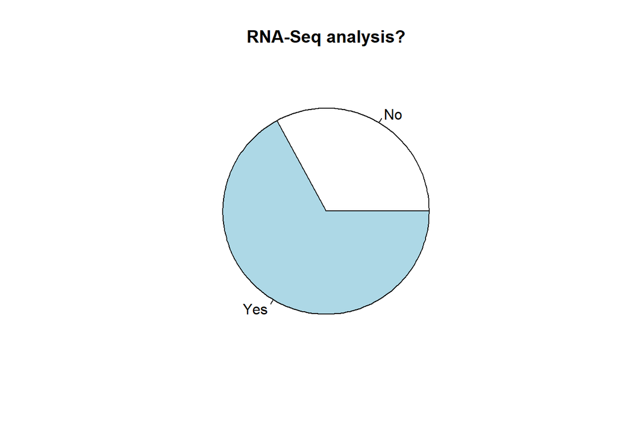

```r
fraqRNAseq = table(data_sample$RNA_SEQ_ANALYSIS)

pie(fraqRNAseq, main = "RNA-Seq analysis?")
```

- **table(data_sample$RNA_SEQ_ANALYSIS)** -> Conta a frequência de cada categoria presente na coluna “RNA_SEQ_ANALYSIS”;
- **pie(table(data_sample$RNA_SEQ_ANALYSIS), main = “RNA-Seq analysis?”)** -> Cria um pie chart que mostra a distribuição dos valores da coluna;

```r
sample_data_rna = data_sample[data_sample$RNA_SEQ_ANALYSIS == 'Yes',]

dim(sample_data_rna)
```

```
## [1] 451  75
```

```r
sum(row.names(sample_data_rna) %in% colnames(RNA_cpm))
```

```
## [1] 451
```

- **sample_data_rna = data_sample[data_sample$RNA_SEQ_ANALYSIS == ‘Yes’,]** -> Filtra o dataframe para icluir apenas os valores que correspondem a “YES”;
- **sum(row.names(sample_data_rna) %in% colnames(RNA_cpm))** -> Calcula o número de linhas em “sample_data_rna” que estão presentes nas colunas do “RNA_cpm”.

O código em cima serviu como filtro para perceber que dados de RNA-seq utilizar nas análises posteriores, garantindo que coincidem com os dados do dataset “RNA_cpm”.

#### 2.2.2.2 data_patient

Começámos por verificar alguns aspetos relativos ao dataset:

```r
class(data_patient)
```

```
## [1] "data.frame"
```

```r
dim(data_patient)
```

```
## [1] 562  22
```

```r
unlist(lapply(data_patient,class))
```

```
##                              PATIENT_ID                                     SEX
##                             "character"                             "character"
##                               ETHNICITY                        AGE_AT_DIAGNOSIS
##                             "character"                               "numeric"
##         MDSMPN_DIAGNOSIS_AT_ACQUISITION NON_AML_MDSMPN_DIAGNOSIS_AT_ACQUISITION
##                             "character"                             "character"
##                            PRIOR_CANCER                            CHEMOTHERAPY
##                             "character"                             "character"
##            PRIORRADIATIONFOROTHERCANCER                               PRIOR_MDS
##                             "character"                             "character"
##                MDS_TWO_MONTHS_PRIOR_AML                            PRIOR_MDSMPN
##                             "character"                             "character"
##             MDSMPN_TWO_MONTHS_PRIOR_AML                               PRIOR_MPN
##                             "character"                             "character"
##                MPN_TWO_MONTHS_PRIOR_AML                  DIAGNOSIS_AT_INCLUSION
##                             "character"                             "character"
##                               DIAGNOSIS                          TREATMENT_TYPE
##                             "character"                             "character"
##                               OS_STATUS                               OS_MONTHS
##                             "character"                               "numeric"
##                   CAUSE_OF_DEATH_SOURCE                                  CENTER
##                             "character"                               "integer"
```

```r
head(row.names(data_patient))
```

```
## [1] "1" "2" "3" "4" "5" "6"
```

```r
row.names(data_patient) <- data_patient$PATIENT_ID

head(row.names(data_patient))
```

```
## [1] "aml_ohsu_2018_17"  "aml_ohsu_2018_29"  "aml_ohsu_2018_45"
## [4] "aml_ohsu_2018_50"  "aml_ohsu_2018_127" "aml_ohsu_2018_163"
```

O dataset corresponde a um dataframe com 562 amostras e 22 variáveis. As colunas possuem três tipos de estrutura de dados (“character”, “integer” e “numeric”), mas iremos transformar em fatores as variáveis não numéricas.

```r
fatores_patient = c(3, 2, 5:19, 21:22)
for (coluna in fatores_patient) {
  data_patient[[coluna]] = as.factor(data_patient[[coluna]])
}

colunas_numericas_patient = c(4,20)
for (coluna in colunas_numericas_patient) {
  data_patient[[coluna]] = as.numeric(data_patient[[coluna]])
}

unlist(lapply(data_patient,class))
```

```
##                              PATIENT_ID                                     SEX
##                             "character"                                "factor"
##                               ETHNICITY                        AGE_AT_DIAGNOSIS
##                                "factor"                               "numeric"
##         MDSMPN_DIAGNOSIS_AT_ACQUISITION NON_AML_MDSMPN_DIAGNOSIS_AT_ACQUISITION
##                                "factor"                                "factor"
##                            PRIOR_CANCER                            CHEMOTHERAPY
##                                "factor"                                "factor"
##            PRIORRADIATIONFOROTHERCANCER                               PRIOR_MDS
##                                "factor"                                "factor"
##                MDS_TWO_MONTHS_PRIOR_AML                            PRIOR_MDSMPN
##                                "factor"                                "factor"
##             MDSMPN_TWO_MONTHS_PRIOR_AML                               PRIOR_MPN
##                                "factor"                                "factor"
##                MPN_TWO_MONTHS_PRIOR_AML                  DIAGNOSIS_AT_INCLUSION
##                                "factor"                                "factor"
##                               DIAGNOSIS                          TREATMENT_TYPE
##                                "factor"                                "factor"
##                               OS_STATUS                               OS_MONTHS
##                                "factor"                               "numeric"
##                   CAUSE_OF_DEATH_SOURCE                                  CENTER
##                                "factor"                                "factor"
```

Depois vamos ver se exitem NAs.

```r
sum(is.na(data_patient))
```

```
## [1] 71
```

- **sum(is.na(data_patient))** -> Calcula a soma de todos os NAs.

Existem 71 NAs, mas em metadados é normal e por isso iremos mantê-los por agora.

Por fim, realizamos a criação de um subset, tal como fizemos com os metadados anteriores, para garantir um dataframe com dados de pacientes presentes em “sample_data_rna”, garantindo assim uma análise aos pacientes para os quais possuimos dados relevantes.

```r
patient_data_rna <- data_patient %>% filter(row.names(data_patient) %in% sample_data_rna$PATIENT_ID)
```

- **patient_data_rna = data_patient %>% filter(data_patient$PATIENT_ID %in% sample_data_rna$PATIENT_ID)** -> Cria um novo dataframe (“patient_data_rna”) filtrando o dataframe (“data_patient”) com base nos IDs dos pacientes presentes no dataframe.

### 2.2.3 data_mutations

Começámos por verificar alguns aspetos relativos ao dataset:

```r
class(data_mutations)
```

```
## [1] "data.frame"
```

```r
dim(data_mutations)
```

```
## [1] 9910   64
```

```r
unlist(lapply(data_mutations,class))
```

```
##                   Hugo_Symbol                Entrez_Gene_Id
##                   "character"                     "integer"
##                        Center                    NCBI_Build
##                   "character"                   "character"
##                    Chromosome                Start_Position
##                   "character"                     "integer"
##                  End_Position                        Strand
##                     "integer"                   "character"
##                   Consequence        Variant_Classification
##                   "character"                   "character"
##                  Variant_Type              Reference_Allele
##                   "character"                   "character"
##             Tumor_Seq_Allele1             Tumor_Seq_Allele2
##                   "character"                   "character"
##                      dbSNP_RS              dbSNP_Val_Status
##                     "logical"                     "logical"
##          Tumor_Sample_Barcode   Matched_Norm_Sample_Barcode
##                   "character"                     "logical"
##        Match_Norm_Seq_Allele1        Match_Norm_Seq_Allele2
##                     "logical"                     "logical"
##      Tumor_Validation_Allele1      Tumor_Validation_Allele2
##                     "logical"                     "logical"
## Match_Norm_Validation_Allele1 Match_Norm_Validation_Allele2
##                     "logical"                     "logical"
##           Verification_Status             Validation_Status
##                     "logical"                   "character"
##               Mutation_Status              Sequencing_Phase
##                   "character"                     "logical"
##               Sequence_Source             Validation_Method
##                     "logical"                     "logical"
##                         Score                      BAM_File
##                     "logical"                     "logical"
##                     Sequencer                   t_ref_count
##                   "character"                     "integer"
##                   t_alt_count                   n_ref_count
##                     "integer"                     "integer"
##                   n_alt_count                         HGVSc
##                     "integer"                   "character"
##                         HGVSp                   HGVSp_Short
##                   "character"                   "character"
```

[output cut: 9 more lines]

```
##                   "character"                   "character"
##            chosen_consequence                        codons
##                   "character"                   "character"
##                  ensembl_gene                       exac_af
##                   "character"                     "numeric"
##            existing_variation                          exon
##                   "character"                   "character"
##                        impact                         n_vaf
##                   "character"                     "numeric"
##                      polyphen                    rna_status
##                   "character"                   "character"
##               short_aa_change                          sift
##                   "character"                   "character"
##                         t_vaf                    tumor_only
##                     "numeric"                     "integer"
```

```r
head(row.names(data_mutations))
```

```
## [1] "1" "2" "3" "4" "5" "6"
```

```r
row.names(data_mutations) = make.unique(data_mutations$Hugo_Symbol)

head(row.names(data_mutations))
```

```
## [1] "C1orf170"   "C1orf170.1" "C1orf170.2" "C1orf170.3" "AGRN"
## [6] "AGRN.1"
```

```r
sum(is.na(data_mutations))
```

```
## [1] 155469
```

- **unlist(lapply(data_mutations,class))** -> Aplica a função class a cada coluna do dataframe;
- **row.names(data_mutations) = make.unique(data_mutations$Hugo_Symbol)** -> Associa os dados presentes na coluna “Hugo_Symbol” com os nomes das linhas nos dataframes, e para evitar duplicados, adiciona um sufixo.

É possível ver que temos um dataframe com 9910 linhas e 64 colunas. No dataframe existem também um número bastante elevados de NAs, 155469.

De seguida, vamos verificar a estrutura interna dos dados de cada coluna:

```r
unlist(lapply(data_mutations,class))
```

```
##                   Hugo_Symbol                Entrez_Gene_Id
##                   "character"                     "integer"
##                        Center                    NCBI_Build
##                   "character"                   "character"
##                    Chromosome                Start_Position
##                   "character"                     "integer"
##                  End_Position                        Strand
##                     "integer"                   "character"
##                   Consequence        Variant_Classification
##                   "character"                   "character"
##                  Variant_Type              Reference_Allele
##                   "character"                   "character"
##             Tumor_Seq_Allele1             Tumor_Seq_Allele2
##                   "character"                   "character"
##                      dbSNP_RS              dbSNP_Val_Status
##                     "logical"                     "logical"
##          Tumor_Sample_Barcode   Matched_Norm_Sample_Barcode
##                   "character"                     "logical"
##        Match_Norm_Seq_Allele1        Match_Norm_Seq_Allele2
##                     "logical"                     "logical"
##      Tumor_Validation_Allele1      Tumor_Validation_Allele2
##                     "logical"                     "logical"
## Match_Norm_Validation_Allele1 Match_Norm_Validation_Allele2
##                     "logical"                     "logical"
##           Verification_Status             Validation_Status
##                     "logical"                   "character"
##               Mutation_Status              Sequencing_Phase
##                   "character"                     "logical"
##               Sequence_Source             Validation_Method
##                     "logical"                     "logical"
##                         Score                      BAM_File
##                     "logical"                     "logical"
##                     Sequencer                   t_ref_count
##                   "character"                     "integer"
##                   t_alt_count                   n_ref_count
##                     "integer"                     "integer"
##                   n_alt_count                         HGVSc
##                     "integer"                   "character"
##                         HGVSp                   HGVSp_Short
##                   "character"                   "character"
```

[output cut: 9 more lines]

```
##                   "character"                   "character"
##            chosen_consequence                        codons
##                   "character"                   "character"
##                  ensembl_gene                       exac_af
##                   "character"                     "numeric"
##            existing_variation                          exon
##                   "character"                   "character"
##                        impact                         n_vaf
##                   "character"                     "numeric"
##                      polyphen                    rna_status
##                   "character"                   "character"
##               short_aa_change                          sift
##                   "character"                   "character"
##                         t_vaf                    tumor_only
##                     "numeric"                     "integer"
```

```r
colunas_fator_mut <- c(1, 9, 10, 11, 12, 13, 14, 15, 16, 18, 19, 20, 21, 22, 23, 24, 25, 26, 27, 28,29,30,31,32, 33, 45, 47, 48, 51, 57, 60, 64)

colunas_numericas_mut <- c(34,35,36,37,43, 54, 58, 63)

colunas_char_mut <- c(2,6,7)

data_mutations[, colunas_fator_mut]<- lapply(data_mutations[, colunas_fator_mut], as.factor)

data_mutations[, colunas_numericas_mut]<- lapply(data_mutations[, colunas_numericas_mut], as.numeric)

data_mutations[, colunas_char_mut]<- lapply(data_mutations[, colunas_char_mut], as.character)
```

- **colunas_fator <- c(1, 9, 10, 11, 12, 13, 14, 15, 16, 18, 19, 20, 21, 22, 23, 24, 25, 26, 27, 28,29,30,31,32, 33, 45, 47, 48, 51, 57, 60, 64)** -> Cria um vetor com colunas para as transformar em fatores;
- **colunas_numericas <- c(34,35,36,37,43, 54, 58, 63)** -> Cria um vetor com colunas para as transformar em valores numéricos;
- **colunas_char <- c(2,6,7)** -> Cria um vetor com colunas para as transformar em caracteres;
- **data_mutations[, colunas_fator]<- lapply(data_mutations[, colunas_fator], as.factor)** -> Transforma as colunas selecionadas anteriormente em fatores;
- **data_mutations[, colunas_numericas]<- lapply(data_mutations[, colunas_numericas], as.numeric)** -> Transforma as colunas selecionadas anteriormente em numéricos;
- **data_mutations[, colunas_char]<- lapply(data_mutations[, colunas_char], as.character)** ->Transforma as colunas selecionadas anteriormente em caracteres;

Ao analisar a estrutura de dados de cada coluna, percebemos que era necessário transformar alguns dos dados para facilitar a sua manipulação:

- os valores das colunas presentes no vetor associado a “colunas_fator” foram transformadas em fatores;
- os valores das colunas presentes no vetor associado a “colunas_numericas” foram transformados em valores numéricos;
- os valores das colunas presentes no vetor associado a “colunas_char” foram transformados em caracteres.

Por fim, procedemos à criação de um subset que contém apenas as linhas de “data_mutations” correspondentes às mutações que estão presentes nos dados de “RNA_cpm” para restringir a análise apenas às mutações para as quais temos dados de expressão gênica.

```r
mutations_subset = data_mutations %>% filter(data_mutations$Hugo_Symbol %in% RNA_cpm$Hugo_Symbol)

head(mutations_subset)
```

```
##          Hugo_Symbol Entrez_Gene_Id   Center NCBI_Build Chromosome
## AGRN            AGRN         375790 ohsu.edu     GRCh37          1
## AGRN.1          AGRN         375790 ohsu.edu     GRCh37          1
## UBE2J2        UBE2J2         118424 ohsu.edu     GRCh37          1
## CPSF3L        CPSF3L          54973 ohsu.edu     GRCh37          1
## CPSF3L.1      CPSF3L          54973 ohsu.edu     GRCh37          1
## ATAD3B        ATAD3B          83858 ohsu.edu     GRCh37          1
##          Start_Position End_Position Strand      Consequence
## AGRN             982281       982281      + missense_variant
## AGRN.1           982281       982281      + missense_variant
## UBE2J2          1192625      1192625      + missense_variant
## CPSF3L          1254771      1254771      + missense_variant
## CPSF3L.1        1254771      1254771      + missense_variant
## ATAD3B          1417649      1417649      + missense_variant
##          Variant_Classification Variant_Type Reference_Allele Tumor_Seq_Allele1
## AGRN          Missense_Mutation          SNP                G                 G
## AGRN.1        Missense_Mutation          SNP                G                 G
## UBE2J2        Missense_Mutation          SNP                T                 T
## CPSF3L        Missense_Mutation          SNP                C                 C
## CPSF3L.1      Missense_Mutation          SNP                C                 C
## ATAD3B        Missense_Mutation          SNP                T                 T
##          Tumor_Seq_Allele2 dbSNP_RS dbSNP_Val_Status   Tumor_Sample_Barcode
## AGRN                     T     <NA>             <NA> aml_ohsu_2018_14-00676
## AGRN.1                   T     <NA>             <NA> aml_ohsu_2018_14-00676
## UBE2J2                   G     <NA>             <NA> aml_ohsu_2018_13-00515
## CPSF3L                   T     <NA>             <NA> aml_ohsu_2018_15-00805
## CPSF3L.1                 T     <NA>             <NA> aml_ohsu_2018_15-00805
## ATAD3B                   G     <NA>             <NA> aml_ohsu_2018_14-00244
##          Matched_Norm_Sample_Barcode Match_Norm_Seq_Allele1
## AGRN                            <NA>                   <NA>
## AGRN.1                          <NA>                   <NA>
## UBE2J2                          <NA>                   <NA>
## CPSF3L                          <NA>                   <NA>
## CPSF3L.1                        <NA>                   <NA>
## ATAD3B                          <NA>                   <NA>
##          Match_Norm_Seq_Allele2 Tumor_Validation_Allele1
## AGRN                       <NA>                     <NA>
## AGRN.1                     <NA>                     <NA>
## UBE2J2                     <NA>                     <NA>
## CPSF3L                     <NA>                     <NA>
```

[output cut: 57 more lines]

```
## ATAD3B     missense_variant Tcc/Gcc ENSG00000160072 0.00567        rs140940347
##           exon   impact      n_vaf                 polyphen rna_status
## AGRN     19/36 MODERATE 0.00000000 probably_damaging(0.972)  not_found
## AGRN.1   19/36 MODERATE 0.00000000 probably_damaging(0.972)  not_found
## UBE2J2     5/8 MODERATE 0.04545454            benign(0.168)      found
## CPSF3L    6/19 MODERATE 0.00000000 probably_damaging(0.957)   not_done
## CPSF3L.1  6/19 MODERATE 0.00000000 probably_damaging(0.957)   not_done
## ATAD3B    6/16 MODERATE 0.00000000            benign(0.001)   not_done
##          short_aa_change              sift      t_vaf tumor_only
## AGRN            p.G1111V    deleterious(0) 0.09352518          0
## AGRN.1          p.G1111V    deleterious(0) 0.10156250          0
## UBE2J2            p.M96L deleterious(0.05) 0.08620690          0
## CPSF3L           p.V118I deleterious(0.01) 0.13793103          0
## CPSF3L.1         p.V118I deleterious(0.01) 0.13953488          0
## ATAD3B           p.S216A      tolerated(1) 0.22222222          0
```

# 3 **Sumarização dos dados**

Criação de dataframe com todos os metadados tendo em conta o ID dos Pacientes associados a cada amostra que tiveram o RNA sequenciado para facilitar o tratamento de metadados.

```r
metadados = merge(sample_data_rna, patient_data_rna, by='PATIENT_ID', all=T)

dim(metadados)
```

```
## [1] 451  96
```

Vamos retirar dos metadados as variáveis que não vamos usar na análise, deixando apenas no dataframe as variáveis de interesse.

```r
colnames(metadados)
```

```
##  [1] "PATIENT_ID"
##  [2] "SAMPLE_ID"
##  [3] "SAMPLE_TIMEPOINT"
##  [4] "FUSION"
##  [5] "SPECIFIC_DIAGNOSIS_AT_INCLUSION"
##  [6] "ELN_2017"
##  [7] "ELN_2008"
##  [8] "SPECIFIC_DIAGNOSIS_AT_ACQUISITION"
##  [9] "GROUP"
## [10] "SAMPLE_SITE"
## [11] "PLATFORM"
## [12] "RNA_SEQUENCED"
## [13] "WHOLE_EXOME_SEQUENCING"
## [14] "EX_VIVO_DRUG_TESTING"
## [15] "RNA_SEQ_ANALYSIS"
```

[output cut: 81 more lines]

```r
row.names(metadados) = metadados$SAMPLE_ID

variaveis_interessantes = c(1:4, 6, 8:10, 18:29, 52, 70, 73, 76:78, 90:95)

metadados = metadados[, variaveis_interessantes]
```

```r
print(dfSummary(metadados, style = 'grid', graph.magnif = 1, valid.col = FALSE,
                max.distinct.values = 5, col.widths = c(100, 200, 200, 350, 500, 250),
                dfSummary.silent  = TRUE, headings = FALSE, justify = 'l')
      , method = 'render', max.tbl.height = 500)
```

| **No** | **Variable** | **Stats / Values** | **Freqs (% of Valid)** | **Graph** | **Missing** |
| --- | --- | --- | --- | --- | --- |
| 1 | PATIENT_ID [character] | 1. aml_ohsu_2018_1973 2. aml_ohsu_2018_2119 3. aml_ohsu_2018_2337 4. aml_ohsu_2018_2694 5. aml_ohsu_2018_4197 [ 406 others ] | 3 ( 0.7% ) 3 ( 0.7% ) 3 ( 0.7% ) 3 ( 0.7% ) 3 ( 0.7% ) 436 ( 96.7% ) |  | 0 (0.0%) |
| 2 | SAMPLE_ID [character] | 1. aml_ohsu_2018_12.00023 2. aml_ohsu_2018_12.00051 3. aml_ohsu_2018_12.00066 4. aml_ohsu_2018_12.00150 5. aml_ohsu_2018_12.00211 [ 446 others ] | 1 ( 0.2% ) 1 ( 0.2% ) 1 ( 0.2% ) 1 ( 0.2% ) 1 ( 0.2% ) 446 ( 98.9% ) |  | 0 (0.0%) |
| 3 | SAMPLE_TIMEPOINT [factor] | 1. After or at the time tran 2. Denovo 3. Relapse 4. Transformation from anoth | 71 ( 22.4% ) 223 ( 70.3% ) 22 ( 6.9% ) 1 ( 0.3% ) |  | 134 (29.7%) |
| 4 | FUSION [factor] | 1. CBFB-MYH11 2. Complex 3. DEK-NUP214 4. GATA2-MECOM 5. MLLT3-KMT2A [ 4 others ] | 26 ( 5.8% ) 3 ( 0.7% ) 3 ( 0.7% ) 8 ( 1.8% ) 13 ( 2.9% ) 398 ( 88.2% ) |  | 0 (0.0%) |
| 5 | ELN_2017 [factor] | 1. Adverse 2. Favorable 3. Favorable or Intermediate 4. Intermediate 5. Intermediate or Adverse 6. Unknown | 162 ( 35.9% ) 117 ( 25.9% ) 14 ( 3.1% ) 150 ( 33.3% ) 7 ( 1.6% ) 1 ( 0.2% ) |  | 0 (0.0%) |
| 6 | SPECIFIC_DIAGNOSIS_AT_ACQUISITION [factor] | 1. Acute erythroid leukaemia 2. Acute megakaryoblastic le 3. Acute monoblastic and mon 4. Acute myeloid leukaemia, 5. Acute myelomonocytic leuk [ 29 others ] | 1 ( 0.2% ) 1 ( 0.2% ) 12 ( 2.7% ) 51 ( 11.3% ) 18 ( 4.0% ) 368 ( 81.6% ) |  | 0 (0.0%) |
| 7 | GROUP [factor] | 1. Initial Acute Leukemia Di 2. Initial Acute Leukemia Di 3. Initial Acute Leukemia Di 4. Post-Chemotherapy 5. Post-Chemotherapy\|Initial [ 36 others ] | 281 ( 62.3% ) 4 ( 0.9% ) 1 ( 0.2% ) 20 ( 4.4% ) 3 ( 0.7% ) 142 ( 31.5% ) |  | 0 (0.0%) |
| 8 | SAMPLE_SITE [factor] | 1. Bone Marrow Aspirate 2. Leukapheresis 3. Peripheral Blood | 239 ( 53.0% ) 9 ( 2.0% ) 203 ( 45.0% ) |  | 0 (0.0%) |
| 9 | CUMULATIVE_TREATMENT_TYPE_COUNT [factor] | 1. 0 2. 1 3. 2 4. 3 5. 4 6. 5 | 22 ( 4.9% ) 227 ( 50.3% ) 162 ( 35.9% ) 35 ( 7.8% ) 4 ( 0.9% ) 1 ( 0.2% ) |  | 0 (0.0%) |
| 10 | CUMULATIVE_TREATMENT_TYPES [factor] | 1. DLI \| Standard Chemothera 2. DLI \| Standard Chemothera 3. DLI \| Standard Chemothera 4. DLI \| Standard Chemothera 5. DLI \| Standard Chemothera [ 31 others ] | 4 ( 0.9% ) 1 ( 0.2% ) 0 ( 0.0% ) 1 ( 0.2% ) 0 ( 0.0% ) 423 ( 98.6% ) |  | 22 (4.9%) |
| 11 | CUMULATIVE_TREATMENT_REGIMEN_COUNT [factor] | 1. 0 2. 1 3. 13 4. 2 5. 3 [ 6 others ] | 22 ( 4.9% ) 101 ( 22.4% ) 2 ( 0.4% ) 93 ( 20.6% ) 96 ( 21.3% ) 137 ( 30.4% ) |  | 0 (0.0%) |
| 12 | CUMULATIVE_TREATMENT_REGIMENS [factor] | 1. 3+7 (Cytarabine, Daunorub 2. 3+7 (Cytarabine, Daunorub 3. 3+7 (Cytarabine, Daunorub 4. 3+7 (Cytarabine, Daunorub 5. 3+7 (Cytarabine, Daunorub [ 359 others ] | 6 ( 1.4% ) 0 ( 0.0% ) 0 ( 0.0% ) 1 ( 0.2% ) 1 ( 0.2% ) 421 ( 98.1% ) |  | 22 (4.9%) |
| 13 | CUMULATIVE_TREATMENT_STAGE_COUNT [factor] | 1. 0 2. 1 3. 2 4. 3 5. 4 [ 4 others ] | 22 ( 4.9% ) 100 ( 22.2% ) 118 ( 26.2% ) 108 ( 23.9% ) 69 ( 15.3% ) 34 ( 7.5% ) |  | 0 (0.0%) |
| 14 | CUMULATIVE_TREATMENT_STAGES [factor] | 1. Allogeneic - Sibling \| Co 2. Allogeneic - Sibling \| Co 3. Allogeneic - Sibling \| Co 4. Allogeneic - Sibling \| Co 5. Allogeneic - Sibling \| Co [ 164 others ] | 6 ( 1.4% ) 1 ( 0.2% ) 0 ( 0.0% ) 1 ( 0.2% ) 3 ( 0.7% ) 418 ( 97.4% ) |  | 22 (4.9%) |
| 15 | INDUCTION_RESPONSE [factor] | 1. Complete Response 2. Complete Response i 3. Refractory 4. Unknown 5. UNKNOWN | 197 ( 54.4% ) 7 ( 1.9% ) 119 ( 32.9% ) 34 ( 9.4% ) 5 ( 1.4% ) |  | 89 (19.7%) |
| 16 | TYPE_INDUCTION_TREATMENT [factor] | 1. Intrathecal 2. Other 3. Standard Chemotherapy 4. Supportive/Palliative Car 5. Targeted Therapy - Kinase | 3 ( 0.8% ) 1 ( 0.3% ) 356 ( 98.3% ) 1 ( 0.3% ) 1 ( 0.3% ) |  | 89 (19.7%) |
| 17 | DURATION_OF_INDUCTION_TREATMENT [numeric] | Mean (sd) : 39.3 (267.7) min ≤ med ≤ max: -1 ≤ 6 ≤ 4626 IQR (CV) : 10.8 (6.8) | 65 distinct values |  | 89 (19.7%) |
| 18 | MOST_RECENT_TREATMENT_TYPE [factor] | 1. Bone Marrow Transplant 2. DLI 3. Intrathecal 4. NONE 5. Other [ 5 others ] | 87 ( 19.3% ) 2 ( 0.4% ) 2 ( 0.4% ) 22 ( 4.9% ) 2 ( 0.4% ) 336 ( 74.5% ) |  | 0 (0.0%) |
| 19 | CURRENT_REGIMEN [factor] | 1. 3+7 (Cytarabine, Daunorub 2. 5+2 (Cytarabine, Idarubic 3. 7+3 (Cytarabine, Idarubic 4. 7+3 (Cytarabine, Idarubic 5. 7+3 (Cytarabine, Idarubic [ 109 others ] | 8 ( 1.8% ) 1 ( 0.2% ) 18 ( 4.0% ) 1 ( 0.2% ) 1 ( 0.2% ) 422 ( 93.6% ) |  | 0 (0.0%) |
| 20 | CURRENT_STAGE [factor] | 1. Allogeneic - Child 2. Allogeneic - Matched Unre 3. Allogeneic - Mismatched U 4. Allogeneic - Sibling 5. CNS [ 14 others ] | 4 ( 0.9% ) 31 ( 6.9% ) 14 ( 3.1% ) 29 ( 6.4% ) 1 ( 0.2% ) 372 ( 82.5% ) |  | 0 (0.0%) |
| 21 | CYTOGENETICS_OTHER [factor] | 1. - 11q23 rearrangement inv 2. - 3 copies of the MECOM l 3. - Gain of chromosome 8 in 4. (D5S2064x3~4,D5S630x3~4, 5. (FISH) was performed with [ 261 others ] | 0 ( 0.0% ) 1 ( 0.3% ) 1 ( 0.3% ) 0 ( 0.0% ) 1 ( 0.3% ) 341 ( 99.1% ) |  | 107 (23.7%) |
| 22 | AGE_AT_PROCUREMENT [numeric] | Mean (sd) : 57.2 (18.1) min ≤ med ≤ max: 2 ≤ 61 ≤ 87 IQR (CV) : 24 (0.3) | 75 distinct values |  | 1 (0.2%) |
| 23 | CANCER_TYPE [factor] | 1. Blastic Plasmacytoid Dend 2. Leukemia 3. Mastocytosis 4. Mature B-Cell Neoplasms 5. Myelodysplastic Syndromes [ 2 others ] | 0 ( 0.0% ) 439 ( 97.3% ) 0 ( 0.0% ) 0 ( 0.0% ) 6 ( 1.3% ) 6 ( 1.3% ) |  | 0 (0.0%) |
| 24 | SEX [factor] | 1. Female 2. Male | 193 ( 42.8% ) 258 ( 57.2% ) |  | 0 (0.0%) |
| 25 | ETHNICITY [factor] | 1. AdmixedAsian 2. AdmixedBlack 3. AdmixedWhite 4. Asian 5. Black [ 2 others ] | 1 ( 0.2% ) 2 ( 0.4% ) 1 ( 0.2% ) 14 ( 3.1% ) 17 ( 3.8% ) 416 ( 92.2% ) |  | 0 (0.0%) |
| 26 | AGE_AT_DIAGNOSIS [numeric] | Mean (sd) : 57 (18) min ≤ med ≤ max: 2 ≤ 61 ≤ 87 IQR (CV) : 25 (0.3) | 78 distinct values |  | 3 (0.7%) |
| 27 | DIAGNOSIS_AT_INCLUSION [factor] | 1. Acute Leukaemias of Ambig 2. Acute Myeloid Leukaemia ( 3. Mature B-Cell Neoplasms 4. Myelodysplastic Syndromes 5. Myelodysplastic/Myeloprol 6. Myeloproliferative Neopla | 2 ( 0.4% ) 437 ( 96.9% ) 0 ( 0.0% ) 6 ( 1.3% ) 2 ( 0.4% ) 4 ( 0.9% ) |  | 0 (0.0%) |
| 28 | DIAGNOSIS [factor] | 1. Acute Leukaemias of Ambig 2. Acute Myeloid Leukaemia ( 3. Mature B-Cell Neoplasms 4. Myelodysplastic Syndromes 5. Myelodysplastic/Myeloprol 6. Myeloproliferative Neopla | 2 ( 0.4% ) 440 ( 97.6% ) 0 ( 0.0% ) 6 ( 1.3% ) 0 ( 0.0% ) 3 ( 0.7% ) |  | 0 (0.0%) |
| 29 | TREATMENT_TYPE [factor] | 1. (Empty string) 2. DLI\|Standard Chemotherapy 3. DLI\|Standard Chemotherapy 4. DLI\|Standard Chemotherapy 5. DLI\|Standard Chemotherapy [ 32 others ] | 22 ( 4.9% ) 4 ( 0.9% ) 1 ( 0.2% ) 0 ( 0.0% ) 1 ( 0.2% ) 423 ( 93.8% ) |  | 0 (0.0%) |
| 30 | OS_STATUS [factor] | 1. (Empty string) 2. 0:LIVING 3. 1:DECEASED | 43 ( 9.5% ) 170 ( 37.7% ) 238 ( 52.8% ) |  | 0 (0.0%) |
| 31 | OS_MONTHS [numeric] | Mean (sd) : 13.9 (15.4) min ≤ med ≤ max: 0 ≤ 10.5 ≤ 174.5 IQR (CV) : 12.2 (1.1) | 289 distinct values |  | 46 (10.2%) |
| 32 | CAUSE_OF_DEATH_SOURCE [factor] | 1. (Empty string) 2. Alive 3. Dead-Disease 4. Dead-Other 5. Dead-Treatment 6. Dead-Unknown | 43 ( 9.5% ) 170 ( 37.7% ) 155 ( 34.4% ) 13 ( 2.9% ) 14 ( 3.1% ) 56 ( 12.4% ) |  | 0 (0.0%) |

Generated by summarytools 1.0.1 ([R](https://www.r-project.org/) version 4.3.1)  
2024-05-06

## 3.1 mutations_subset

```r
colunas_relevantes = c("Chromosome", "Start_Position", "End_Position", "Strand", "Variant_Classification", "Variant_Type", "Tumor_Seq_Allele1", "Tumor_Seq_Allele2", "Validation_Status", "Mutation_Status", "impact", "n_vaf")

relev_data_mutations = mutations_subset[, colunas_relevantes]
```

```r
print(dfSummary(relev_data_mutations, style = 'grid', graph.magnif = 1, valid.col = FALSE,
                max.distinct.values = 5, col.widths = c(100, 200, 200, 350, 500, 250),
                dfSummary.silent  = TRUE, headings = FALSE, justify = 'l')
      , method = 'render', max.tbl.height = 500)
```

| **No** | **Variable** | **Stats / Values** | **Freqs (% of Valid)** | **Graph** | **Missing** |
| --- | --- | --- | --- | --- | --- |
| 1 | Chromosome [character] | 1. 2 2. 1 3. 17 4. 11 5. 19 [ 19 others ] | 743 ( 9.1% ) 694 ( 8.5% ) 546 ( 6.7% ) 459 ( 5.6% ) 454 ( 5.6% ) 5249 ( 64.4% ) |  | 0 (0.0%) |
| 2 | Start_Position [character] | 1. 170837543 2. 90631934 3. 74732959 4. 25457242 5. 209113113 [ 3891 others ] | 109 ( 1.3% ) 107 ( 1.3% ) 106 ( 1.3% ) 97 ( 1.2% ) 69 ( 0.8% ) 7657 ( 94.0% ) |  | 0 (0.0%) |
| 3 | End_Position [character] | 1. 170837544 2. 74732959 3. 90631934 4. 25457242 5. 209113113 [ 3891 others ] | 109 ( 1.3% ) 109 ( 1.3% ) 107 ( 1.3% ) 97 ( 1.2% ) 69 ( 0.8% ) 7654 ( 94.0% ) |  | 0 (0.0%) |
| 4 | Strand [character] | 1. + | 8145 ( 100.0% ) |  | 0 (0.0%) |
| 5 | Variant_Classification [factor] | 1. Frame_Shift_Del 2. Frame_Shift_Ins 3. In_Frame_Del 4. In_Frame_Ins 5. Intron [ 5 others ] | 309 ( 3.8% ) 388 ( 4.8% ) 228 ( 2.8% ) 177 ( 2.2% ) 1 ( 0.0% ) 7042 ( 86.5% ) |  | 0 (0.0%) |
| 6 | Variant_Type [factor] | 1. DEL 2. INS 3. SNP | 566 ( 6.9% ) 580 ( 7.1% ) 6999 ( 85.9% ) |  | 0 (0.0%) |
| 7 | Tumor_Seq_Allele1 [factor] | 1. - 2. A 3. AA 4. AAAG 5. AAC [ 141 others ] | 580 ( 7.1% ) 804 ( 9.9% ) 1 ( 0.0% ) 2 ( 0.0% ) 1 ( 0.0% ) 6757 ( 83.0% ) |  | 0 (0.0%) |
| 8 | Tumor_Seq_Allele2 [factor] | 1. - 2. A 3. AA 4. AAATTTTCTCTTGGAAACTCCCATT 5. AACCAAACTCTAAATTTTCTCTTGG [ 210 others ] | 566 ( 6.9% ) 2520 ( 30.9% ) 3 ( 0.0% ) 1 ( 0.0% ) 1 ( 0.0% ) 5054 ( 62.1% ) |  | 0 (0.0%) |
| 9 | Validation_Status [factor] | 1. not_covered 2. not_done 3. not_found 4. validated | 495 ( 6.1% ) 6604 ( 81.1% ) 85 ( 1.0% ) 961 ( 11.8% ) |  | 0 (0.0%) |
| 10 | Mutation_Status [factor] | 1. Somatic | 8145 ( 100.0% ) |  | 0 (0.0%) |
| 11 | impact [factor] | 1. HIGH 2. MODERATE 3. MODIFIER | 1577 ( 19.4% ) 6525 ( 80.1% ) 43 ( 0.5% ) |  | 0 (0.0%) |
| 12 | n_vaf [numeric] | Mean (sd) : 0 (0) min ≤ med ≤ max: 0 ≤ 0 ≤ 1 IQR (CV) : 0 (2.4) | 630 distinct values |  | 0 (0.0%) |

Generated by summarytools 1.0.1 ([R](https://www.r-project.org/) version 4.3.1)  
2024-05-06

# 4 **Análise exploratória**

## 4.1 Metadados dos pacientes

Considerando variáveis relevantes:

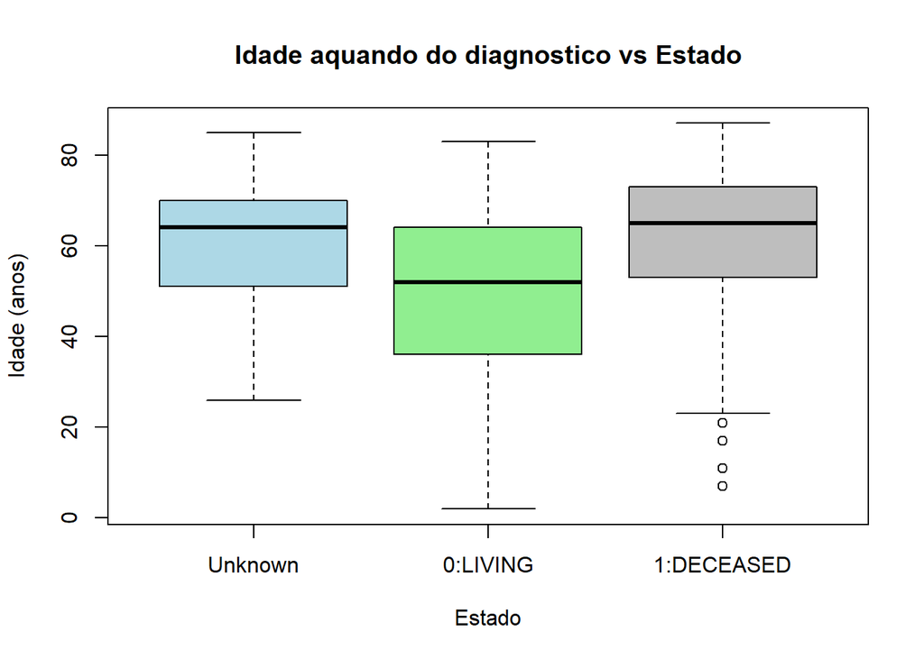

```r
boxplot(AGE_AT_DIAGNOSIS ~ OS_STATUS, data = metadados, main = "Idade aquando do diagnostico vs Estado", xlab = "Estado", ylab = "Idade (anos)", col = c("lightblue", "lightgreen", "grey"), names = c("Unknown", "0:LIVING", "1:DECEASED"))
```

O código em cima cria um boxplot que compara as distribuições das idades aquando do diagnóstico entre os diferentes estados de sobrevida. É possível observar que a idade com que foram diagnosticados não parece ter uma influência ou associação significativa com a sobrevivência do paciente, embora a idade aquando do diagnóstico seja menor nos pacientes que ainda estão vivos, o que pode ter a ver com o facto da rapidez de diagnóstico estar normalmente associada a uma maior taxa de sobrevivência.

De seguida, decidimos averiguar a distribuição das etnias:

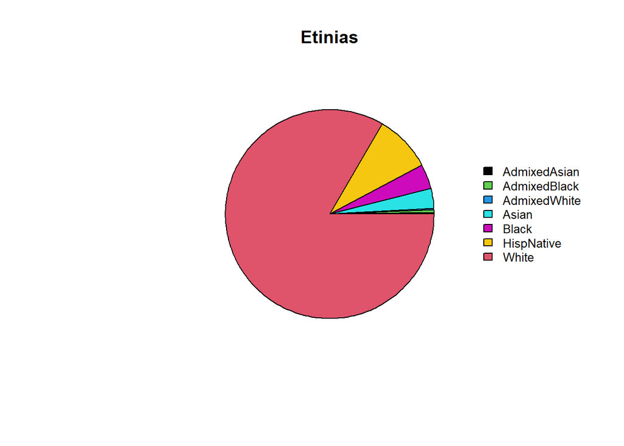

```r
valores = table(metadados$ETHNICITY)

nome = c("AdmixedAsian", "AdmixedBlack", "AdmixedWhite", "Asian", "Black", "HispNative", "White")

pie(valores, labels = rep("", length(valores)), col = c("black",3,4,5,6,7,2), main = "Etinias")
legend("right", legend = nome, bty = "n", cex = 0.8, fill = c("black",3,4,5,6,7,2))
```

Verificámos que as etnias mais representadas neste dataset são “White”, “Hispanic Native”, “Black” e “Asian” respetivamente.

De seguida, procedemos à comparação da idade de diagnóstico entre os géneros

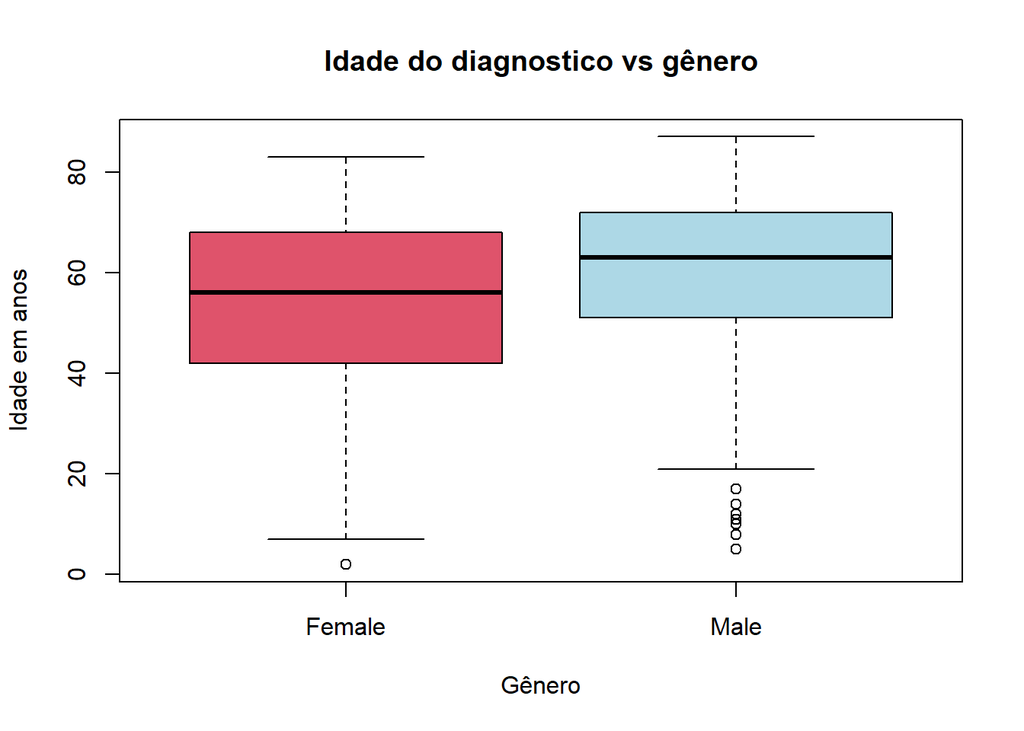

```r
boxplot(AGE_AT_DIAGNOSIS ~ SEX, data = metadados, main = "Idade do diagnostico vs gênero", xlab = "Gênero", ylab = "Idade em anos", col = c(2,'lightblue'))
```

No boxplot é possível observar que a idade dos pacientes masculinos, é ligeiramente mais elevada, possuindo limites, quartis e mediana com idades superiores comparativamente aos pacientes femininos. Verifica-se também uma maior presença de outliers nos dados dos pacientes masculinos comparativamente aos femininos.

Finalmente, fizemos uma análise sobre o diagnóstico mais recorrente que revelou ser ‘Acute Myeloid Leukaemia (AML) and Related Precursor Neoplasms’.

```r
d = table(metadados$DIAGNOSIS)

d = as.data.frame(d)

indice_maximo <- which.max(d$Freq)

nome_maximo <- d$Var1[indice_maximo]

nome_maximo
```

```
## [1] Acute Myeloid Leukaemia (AML) and Related Precursor Neoplasms
## 6 Levels: Acute Leukaemias of Ambiguous Lineage ...
```

## 4.2 Metadados das amostras

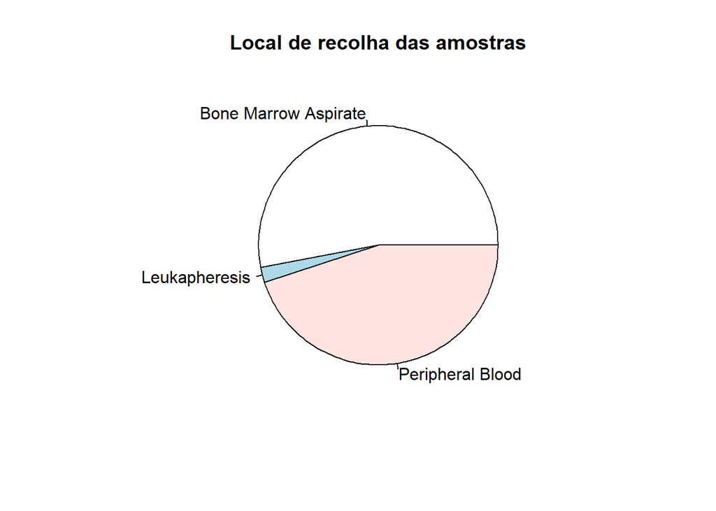

```r
pie(table(metadados$SAMPLE_SITE), main = "Local de recolha das amostras")
```

O gráfico demonstra como as amostras estão distribuídas pelos locais de recolha. Os locais de recolha de amostra mais frequentes entre os dados analisados são o “Aspirado de Medula Óssea” com pouco mais de 50% das amostras, o “Sangue Periférico” com uma distribuição pouco menor do que 50% das amostras, e a “Leucaferese” com opção menos utilizada.

Por último verificamos qual o nome do grupo de diagnóstico mais frequente nos dados

```r
x = table(metadados$GROUP)

x = as.data.frame(x)

indice_maximo <- which.max(x$Freq)

nome_maximo <- x$Var1[indice_maximo]

nome_maximo
```

```
## [1] Initial Acute Leukemia Diagnosis
## 41 Levels: Initial Acute Leukemia Diagnosis ...
```

## 4.3 mutations_subset

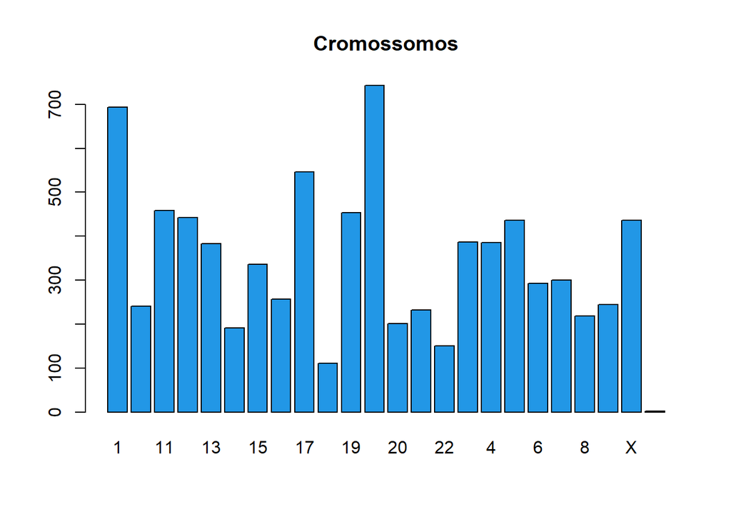

```r
barplot(table(relev_data_mutations$Chromosome), main = "Cromossomos", col = "4")
```

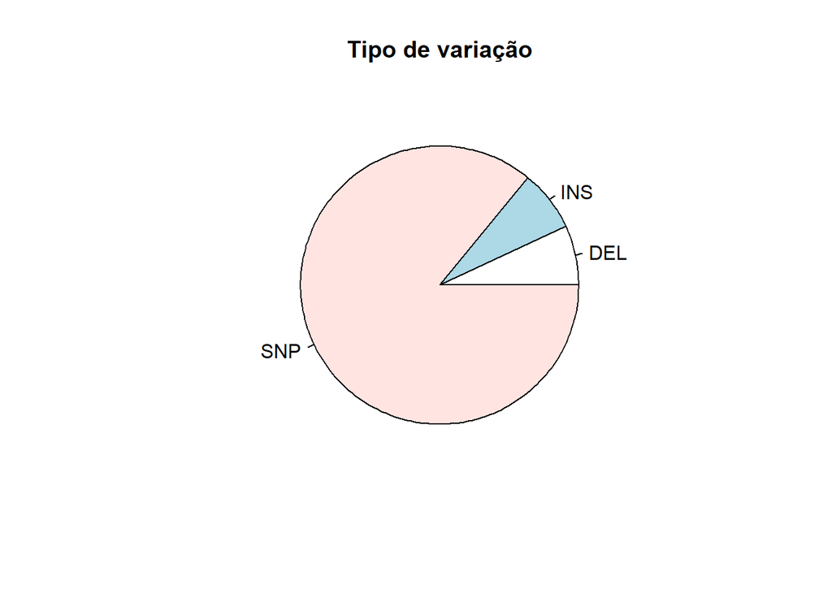

```r
pie(table(relev_data_mutations$Variant_Type), main = "Tipo de variação")
```

Com o código em cima, geramos um gráfico de barras que mostra a contagem de ocorrências de cada cromossoma, e um gráfico de pizza para perceber a distribuição dos tipos de variantes no dataframe.

É possível observar que a variante mais frequente no dataframe é a “SNP”, seguida da “INS” e da “DEL”.

Depois, verificamos qual a mutação mais comum no Alelo 1 entre as amostras analisadas

```r
mut = table(relev_data_mutations$Tumor_Seq_Allele1)

mut = as.data.frame(mut)

indice_maximo <- which.max(mut$Freq)

nome_maximo <- mut$Var1[indice_maximo]

nome_maximo
```

```
## [1] C
## 146 Levels: - A AA AAAG AAC AACCAAAATATGCAGGG AACTCCAT AAG AAGTAAGAG ... TTGAAGAGTT
```

A mutação mais comum referente ao Alelo 1, é a alteração por Citosinas. Este dado pode ser útil na identificação de uma doença ou de um potêncial alvo terapêutico.

Analisamos ainda qual a mutação mais comum no Alelo 2 entre as amostras analisadas:

```r
mut2 = table(relev_data_mutations$Tumor_Seq_Allele2)

mut2 = as.data.frame(mut2)

indice_maximo <- which.max(mut2$Freq)

nome_maximo <- mut2$Var1[indice_maximo]

nome_maximo # A mutação mais comum é a alteração por T
```

```
## [1] T
## 215 Levels: - A AA ... TTTTCTCTTGGAAACTCCCATTTGAGATCATATTCATATTCTCTGAAATCAACGTAGAAG
```

Já no Alelo 2, a mutação mais comum é a alteração por Timina.

# 5 **Análise Univariada**

## 5.1 Análise com as variáveis do metadado dos pacientes

As variáveis analisadas foram: Idade e sexo dos pacientes, teve como objectivo de determinar se os dois grupos de sexo (“Male” e “Female”) deferiam quanto as idades. Para fazer esta análise, foi avaliado se os dois diferentes grupos apresentam médias diferentes.

```r
table(metadados$SEX) # Confirmação de quantos grupos de sexos há.
```

```
##
## Female   Male
##    193    258
```

```r
# Testar a homogeneidade das variâncias
leveneTest(metadados$AGE_AT_DIAGNOSIS~metadados$SEX) # Não rejeitar a hipótese de que as variâncias dos grupos são iguais.
```

```
## Levene's Test for Homogeneity of Variance (center = median)
##        Df F value Pr(>F)
## group   1  2.6499 0.1043
##       446
```

```r
# Testar a normalidade dos diferentes grupos
teste_normalidade_masculino=shapiro.test(metadados$AGE_AT_DIAGNOSIS[metadados$SEX == "Male"])
teste_normalidade_feminino=shapiro.test(metadados$AGE_AT_DIAGNOSIS[metadados$SEX == "Female"])
print(teste_normalidade_masculino) # Não normal
```

```
##
##  Shapiro-Wilk normality test
##
## data:  metadados$AGE_AT_DIAGNOSIS[metadados$SEX == "Male"]
## W = 0.91858, p-value = 1.387e-10
```

```r
print(teste_normalidade_feminino) # Não normal
```

```
##
##  Shapiro-Wilk normality test
##
## data:  metadados$AGE_AT_DIAGNOSIS[metadados$SEX == "Female"]
## W = 0.96197, p-value = 4.514e-05
```

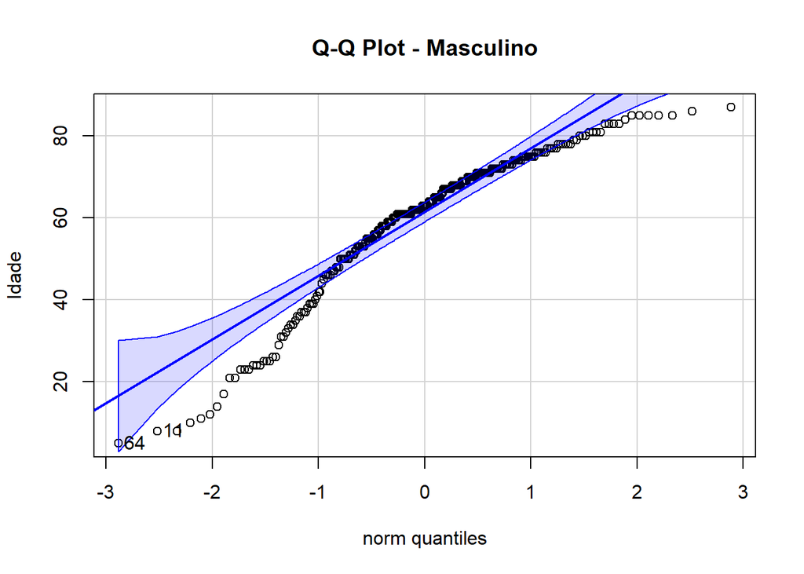

```
## [1] 64 11
```

```r
# Visualização da normalidade com qqPlot
qqPlot(metadados$AGE_AT_DIAGNOSIS[metadados$SEX == "Male"], main = "Q-Q Plot - Masculino", ylab = "Idade")
```

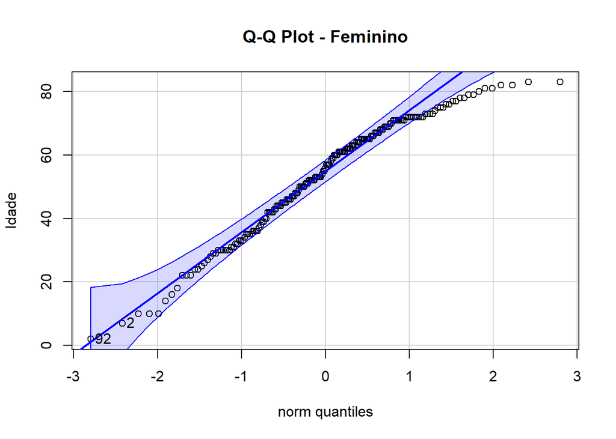

```
## [1] 92  2
```

```r
qqPlot(metadados$AGE_AT_DIAGNOSIS[metadados$SEX == "Female"], main = "Q-Q Plot - Feminino", ylab = "Idade")
```

```r
# Normalidade geral das idades
shapiro.test(metadados$AGE_AT_DIAGNOSIS) # Não normal
```

```
##
##  Shapiro-Wilk normality test
##
## data:  metadados$AGE_AT_DIAGNOSIS
## W = 0.94307, p-value = 4.378e-12
```

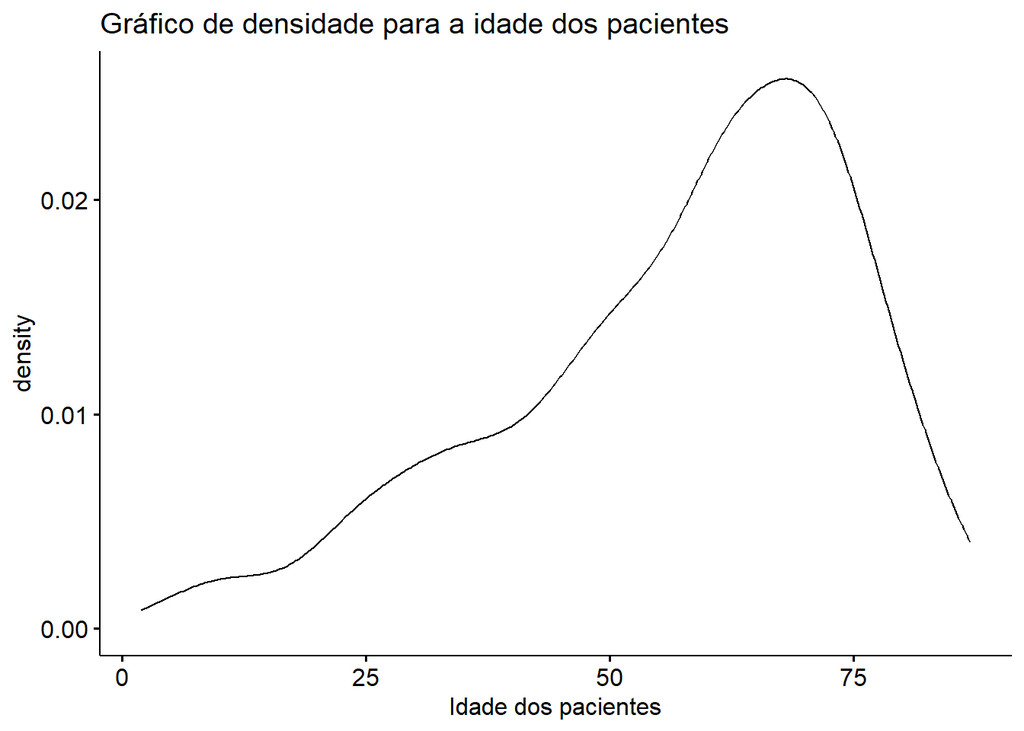

```r
# Retirada dos NAs:
idades_sem_na <- na.omit(metadados$AGE_AT_DIAGNOSIS)

# Criar gráfico de densidade sem valores ausentes
ggdensity(idades_sem_na,
          main = "Gráfico de densidade para a idade dos pacientes",
          xlab = "Idade dos pacientes")
```

Não pode rejeitar a hipótese nula, nesse caso que as variâncias são homogéneas, e com os gráficos qqPlot e as análises de normalidade, foi possível determinar que as distribuições não são normais, mas considerando um tamanho elevado das amostras, realizamos um t-test e analisar relação entre sexo e idade.

```r
# T-test
t.test(metadados$AGE_AT_DIAGNOSIS ~ metadados$SEX, na.rm = TRUE)
```

```
##
##  Welch Two Sample t-test
##
## data:  metadados$AGE_AT_DIAGNOSIS by metadados$SEX
## t = -3.663, df = 407.88, p-value = 0.0002822
## alternative hypothesis: true difference in means between group Female and group Male is not equal to 0
## 95 percent confidence interval:
##  -9.55133 -2.87988
## sample estimates:
## mean in group Female   mean in group Male
##             53.41969             59.63529
```

Com base na análise final, é possível concluir que as idades diferem para os grupos “Male” e “Female”. Isso implicaria que deve levar em consideração em análises de expressão com diferentes sexos que determinadas diferenças podem ser decorrentes da idade.

## 5.2 Análise de varáveis no metadado de mutações

- “n_vaf” (Frequência do Alelo Variante Normalizado),é a frequência do alelo variante, sendo uma variável numérica.
- Impact: variável que se refere ao efeito ou consequência que uma determinada mutação pode ter em um gene ou em uma função biológica específica. É uma variável nominal.

O objectivo dessa comparação é determinar se a frequência do alelo variante defere para diferentes impactos que as mutações apresentam, podendo ser útil para identificar mutações driver (aquelas que contribuem para a progressão e desnvolvimento do câncer).

```r
# Avaliar a variável "N_vaf" quanto a presença de NAs e distribuição
sum(is.na(relev_data_mutations$n_vaf))
```

```
## [1] 0
```

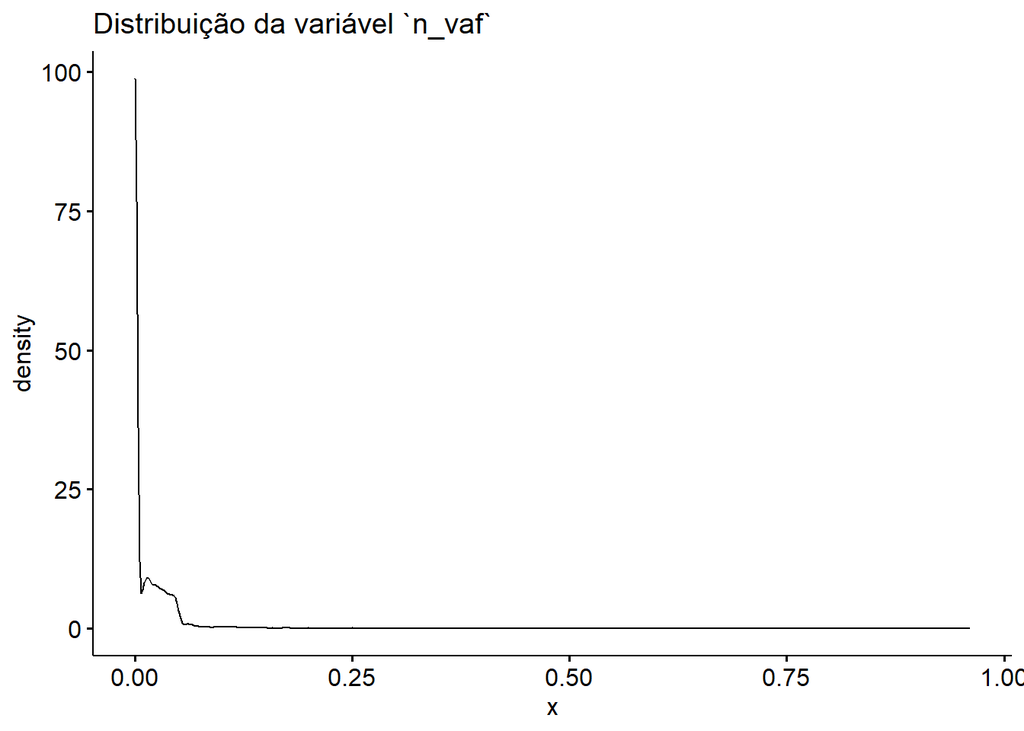

```r
ggdensity(relev_data_mutations$n_vaf, main = "Distribuição da variável `n_vaf`")
```

```r
# Avaliação das diferentes classes de impacto
table(relev_data_mutations$impact) # Há 3 classes: "High", "Moderate" e "Modifier"
```

```
##
##     HIGH MODERATE MODIFIER
##     1577     6525       43
```

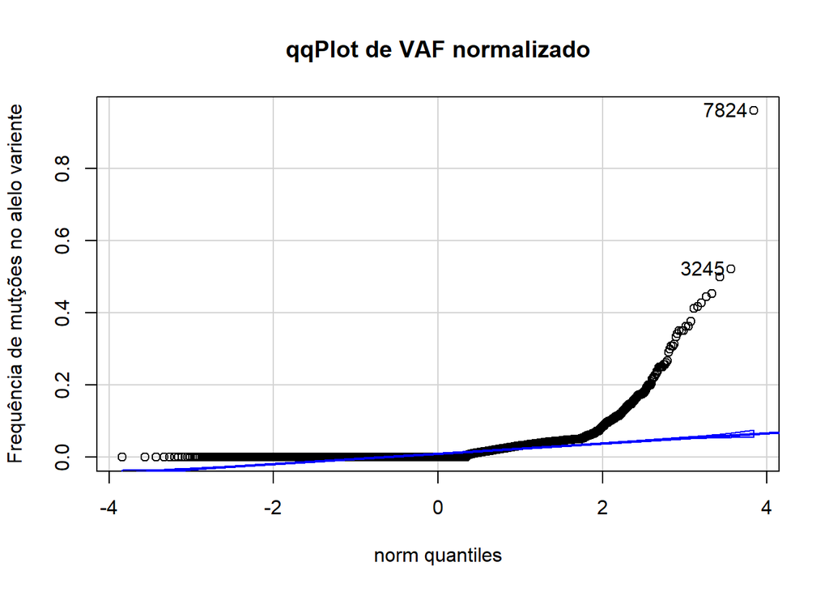

```
## [1] 7824 3245
```

```r
# Avaliar a normalidade de n_vaf
qqPlot(relev_data_mutations$n_vaf, ylab = "Frequência de mutções no alelo variente",  main = "qqPlot de VAF normalizado") # não é normal
```

```r
# Avaliar a homegneidade das variâncias
leveneTest(relev_data_mutations$n_vaf~relev_data_mutations$impact) # as variâncias entre diferentes grupos de impacto não são homogéneas.
```

```
## Levene's Test for Homogeneity of Variance (center = median)
##         Df F value    Pr(>F)
## group    2  7.2159 0.0007395 ***
##       8142
## ---
## Signif. codes:  0 '***' 0.001 '**' 0.01 '*' 0.05 '.' 0.1 ' ' 1
```

```r
# Teste se as medianas são ou não igaus para os diferentes grupos
res = kruskal.test(relev_data_mutations$n_vaf~relev_data_mutations$impact, data = relev_data_mutations)
res # Não são estatisticamente diferentes
```

```
##
##  Kruskal-Wallis rank sum test
##
## data:  relev_data_mutations$n_vaf by relev_data_mutations$impact
## Kruskal-Wallis chi-squared = 3.4471, df = 2, p-value = 0.1784
```

Com os resultados obtidos, não é possível rejeitar a hipótese nula que as medianas são iguais, nesse caso significa que não há variações significativas entre as frequências de mutações dos alelos variantes para diferentes grupos de impacto.

## 5.3 Análise para variáveis do metadado das amostra

- “AGE_AT_PROCUREMENT” - Idade dos pacientes na aquisição das amostras.
- “ELN_2017” - variável usada para classificar pacientes com leucemia mieloide aguda (LMA) em diferentes grupo de risco.

Esta análise tem como objectivo avaliar se a idade tem associação com diferentes grupos de risco.

```r
# Avaliação das variáveis
table(metadados$ELN_2017) # Há 6 grupos de clssificações de risco
```

```
##
##                   Adverse                 Favorable Favorable or Intermediate
##                       162                       117                        14
##              Intermediate   Intermediate or Adverse                   Unknown
##                       150                         7                         1
```

```r
summary(metadados$AGE_AT_PROCUREMENT) # Há um NA.
```

```
##    Min. 1st Qu.  Median    Mean 3rd Qu.    Max.    NA's
##    2.00   47.00   61.00   57.16   71.00   87.00       1
```

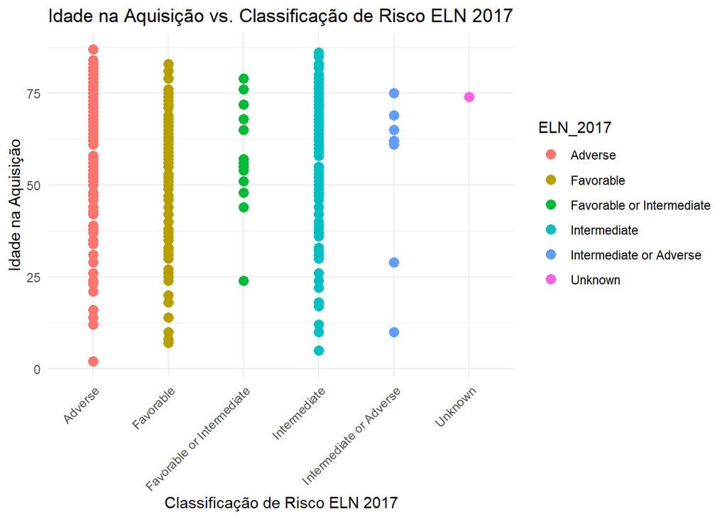

```r
# Criar o gráfico de dispersão
ggplot(metadados, aes(x = ELN_2017, y = AGE_AT_PROCUREMENT, color = ELN_2017)) +
  geom_point(size = 3) +
  labs(x = "Classificação de Risco ELN 2017", y = "Idade na Aquisição", title = "Idade na Aquisição vs. Classificação de Risco ELN 2017") +
  theme_minimal() +
  theme(axis.text.x = element_text(angle = 45, hjust = 1))
```

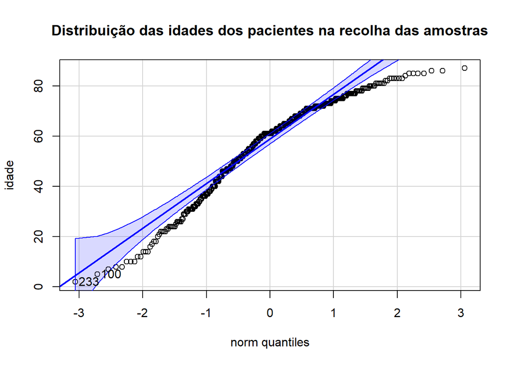

```
## [1] 233 100
```

```r
# Analisando a normalidade e homogeneidade das variâncias:

qqPlot(metadados$AGE_AT_PROCUREMENT, ylab = "idade", main = "Distribuição das idades dos pacientes na recolha das amostras")
```

```r
shapiro.test(metadados$AGE_AT_PROCUREMENT) # Não é normal
```

```
##
##  Shapiro-Wilk normality test
##
## data:  metadados$AGE_AT_PROCUREMENT
## W = 0.94194, p-value = 2.921e-12
```

```r
# Análise da variância
leveneTest(AGE_AT_PROCUREMENT ~ ELN_2017, data = metadados) # Homogénea
```

```
## Levene's Test for Homogeneity of Variance (center = median)
##        Df F value Pr(>F)
## group   5  0.6718  0.645
##       444
```

```r
# ANOVA
anova_result <- aov(AGE_AT_PROCUREMENT ~ ELN_2017, data = metadados)
summary(anova_result)
```

```
##              Df Sum Sq Mean Sq F value  Pr(>F)
## ELN_2017      5   5007  1001.4    3.14 0.00849 **
## Residuals   444 141585   318.9
## ---
## Signif. codes:  0 '***' 0.001 '**' 0.01 '*' 0.05 '.' 0.1 ' ' 1
## 1 observation deleted due to missingness
```

```r
## Análise por grupo:
tukey_result <- TukeyHSD(anova_result)
print(tukey_result)
```

```
##   Tukey multiple comparisons of means
##     95% family-wise confidence level
##
## Fit: aov(formula = AGE_AT_PROCUREMENT ~ ELN_2017, data = metadados)
##
## $ELN_2017
##                                                        diff         lwr
## Favorable-Adverse                                 -7.900285 -14.1014062
## Favorable or Intermediate-Adverse                 -1.671958 -15.9101015
## Intermediate-Adverse                              -1.418842  -7.2204462
## Intermediate or Adverse-Adverse                   -6.814815 -26.5461008
## Unknown-Adverse                                   14.185185 -37.0838165
## Favorable or Intermediate-Favorable                6.228327  -8.2259795
## Intermediate-Favorable                             6.481443   0.1678977
## Intermediate or Adverse-Favorable                  1.085470 -18.8023626
## Unknown-Favorable                                 22.085470 -29.2439832
## Intermediate-Favorable or Intermediate             0.253116 -14.0343502
## Intermediate or Adverse-Favorable or Intermediate -5.142857 -28.8028809
## Unknown-Favorable or Intermediate                 15.857143 -37.0482785
## Intermediate or Adverse-Intermediate              -5.395973 -25.1628798
## Unknown-Intermediate                              15.604027 -35.6786943
## Unknown-Intermediate or Adverse                   21.000000 -33.6404843
##                                                         upr     p adj
## Favorable-Adverse                                 -1.699164 0.0040095
## Favorable or Intermediate-Adverse                 12.566186 0.9994314
## Intermediate-Adverse                               4.382763 0.9818917
## Intermediate or Adverse-Adverse                   12.916471 0.9214985
## Unknown-Adverse                                   65.454187 0.9688297
## Favorable or Intermediate-Favorable               20.682634 0.8203137
## Intermediate-Favorable                            12.794989 0.0403362
## Intermediate or Adverse-Favorable                 20.973303 0.9999870
## Unknown-Favorable                                 73.414923 0.8212244
## Intermediate-Favorable or Intermediate            14.540582 1.0000000
## Intermediate or Adverse-Favorable or Intermediate 18.517167 0.9893781
## Unknown-Favorable or Intermediate                 68.762564 0.9561241
## Intermediate or Adverse-Intermediate              14.370933 0.9705978
## Unknown-Intermediate                              66.886748 0.9532548
## Unknown-Intermediate or Adverse                   75.640484 0.8812628
```

# 6 **Expressão diferencial**

Após uma análise exploratória, concluimos que seria interessante tentar perceber se o sexo, tipo de amostras, o nº e fase dos tratamentos cumulativos e a sobrevivência dos pacientes estavam refletidos nos dados de expressão génica através da análise de expressão diferencial.

Dado que os nossos dados já sofreram uma normalização TMM e são valores CPM, um pré-processamento equivalente à função <cpm(calcNormFactors(y))> (onde y seria o objeto DGElist que teria as raw counts) normalmente utilizada aquando da análise de expressão diferencial com o package limma.Por isso, iremos fazer uma transformação logaritmica para finalizar o processo de normalização dos dados normalmente feito antes da análise da expressão génica diferencial com o limma.

Dado que os nossos dados já sofreram uma normalização TMM e são valores CPM, um pré-processamento equivalente à função <cpm(calcNormFactors(y))> (onde y seria o objeto DGElist que teria as raw counts) normalmente utilizada aquando da análise de expressão diferencial com o package limma.Por isso, filtramos os genes para que apenas aqueles que tenham pelo menos metade dos pacientes com CPM superior a 1 fossem analisados e depois fizémos uma transformação logaritmica para finalizar o processo de normalização dos dados que é normalmente feito antes da análise da expressão génica diferencial com o limma (pipeline limma-trend).

Na maioria das comparações realizadas não foram encontrados genes diferencialmente expressos. Relativamente ao sexo, em contraste com o que foi encontrado no artigo, não foram encontrados genes diferencialmente expressos, sugerindo que o sexo não é um fator diferencial da expressão dos genes nas amostras destes pacientes. Na análise da expressão tendo em conta o tipo de amostra retirada (medula óssea, plasma do sangue periférico ou glóbulos brancos através de leucaférese (Leukapheresis), foram detetados alguns genes diferencialmente expressos entre as amostras. Na comparação entre glóbulos brancos e sangue periférico foram encontrados 2 genes subexpressos e 1 sobrexpresso, enquanto que para o contraste entre glóbulos brancos e medula foram encontrados 1 gene subexpresso e 2 sobrexpressos.No vulcano plot é ainda possível ver o nome dos genes diferencialmente expressos, sendo interessante destacar a presença dos mesmos genes na comparação dos genes diferencialmente expressos entre os glóbulos brancos e o plasma do sangue periférico, e entre os glóbulos brancos e a medula óssea, sendo que os genes subexpressos numa comparação são os que estão sobrepxressos na outra. Esta presença comum nas comparações sugere que a razão para a expressão diferencial destes 3 genes está associada aos globulos brancos, dado serem o elemento em comum nas duas comparações feitas. Adicionalmente, também é interessante destacar a função destes genes diferencialmente expressos como, por exemplo, do gene STK24 que codifica uma proteína quinase envolvida na regulação da apoptose e na resposta ao stress celular e do gene CHFR que está envolvido na regulação do ciclo celular e na manutenção da integridade do genoma, sendo que alterações no gene CHFR, assim como na sua expressão, já foram associadas a vários tipos de cancro, incluindo a LMA. Da mesma forma, alguns genes relacionados com o ciclo celular e resposta ao stress celular (e.g. DNAJC15 e TP73), manutenção da integridade e função celular (e.g. TIMP1, GDP2 e MICAL1) e regulação da expressão génica (e.g. GCFC2), foram encontrados diferencialmente expressos na comparação da fase mais avançada de tratamentos (fase 8) com os outros estados de tratamentos cumulativos e na comparação do nº de tratamentos cumulativos mais elevado com quantidades mais baixas de tratamentos a que os pacientes foram sujeitos. Em conjunto estes resultados sugerem que os tratamentos para a LMA podem afetar a expressão génica de várias maneiras, incluindo a regulação de genes envolvidos na resposta ao stress celular, na proliferação celular e na diferenciação celular. Adicionalmente, a alteração na expressão destes genes pode estar associada à resposta do paciente ao tratamento ou até indicar a eficácia do tratamento.

```r
selected_genes = rowMeans(RNA_cpm[,-1] > 1) > 0.5
RNA_cpm_filtered = RNA_cpm[selected_genes, ]
RNA_cpm_filtered = RNA_cpm_filtered[, -1]

logCPM = log2(RNA_cpm_filtered + 1)
head(logCPM)
```

[output not shown]

[output cut: 1002 more lines]

```
## FUCA2                  5.416202               5.073717              3.8797937
##          aml_ohsu_2018_16.01254 aml_ohsu_2018_16.01262 aml_ohsu_2018_16.01270
## DPM1                   4.739710               5.117007              4.1354557
## SCYL3                  4.491655               4.126069              4.1054048
## C1orf112               3.529989               3.270204              2.9898663
## FGR                   10.321571               5.541185              5.7251653
## CFH                    1.339436               4.741367              0.3121198
## FUCA2                  5.344520               5.563567              5.4641258
##          aml_ohsu_2018_16.01272
## DPM1                   4.751082
## SCYL3                  3.283180
## C1orf112               3.290601
## FGR                    9.141490
## CFH                    1.842117
## FUCA2                  5.846783
```

```r
y <- DGEList(counts = logCPM, genes = row.names(logCPM))
```

Depois da filtragem, ficámos com 14405 genes para a análise de expressão diferencial.

## 6.1 Variável: Sexo

```r
table(metadados$SEX)
```

```
##
## Female   Male
##    193    258
```

```r
design_sex = model.matrix(~0+metadados$SEX, data = y$samples)
colnames(design_sex) = levels(metadados$SEX)
row.names(design_sex) = colnames(logCPM)

contrast_sex = makeContrasts(Female - Male, levels = design_sex)
fit_sex = lmFit(logCPM, design_sex)
fit_sex = contrasts.fit(fit_sex, contrast_sex)
fit_sex = eBayes(fit_sex, trend=T)

topTable(fit = fit_sex, genelist = row.names(logCPM))
```

```
##                        ID      logFC  AveExpr         t      P.Value adj.P.Val
## TPSAB1             TPSAB1  0.7716711 4.046343  3.522269 0.0004712917 0.9849793
## ATXN2L             ATXN2L  0.1086042 8.243601  3.476984 0.0005560338 0.9849793
## FAM83H             FAM83H -0.4075476 2.708250 -3.468771 0.0005728530 0.9849793
## XRCC6P1           XRCC6P1  0.1193470 1.352673  3.460084 0.0005911598 0.9849793
## MFAP4               MFAP4  0.5439896 2.252102  3.354598 0.0008616469 0.9849793
## NUDT14             NUDT14 -0.2692487 2.160386 -3.345160 0.0008907699 0.9849793
## MICAL2             MICAL2 -0.3898636 5.596776 -3.325347 0.0009549085 0.9849793
## RP11-38J22.6 RP11-38J22.6  0.5529369 2.812527  3.299657 0.0010444657 0.9849793
## MICALCL           MICALCL -0.3243349 2.072224 -3.283271 0.0011055992 0.9849793
## RP1-239B22.5 RP1-239B22.5 -0.2153581 1.173921 -3.229869 0.0013286282 0.9849793
##                       B
## TPSAB1       -0.7580676
## ATXN2L       -0.8712647
## FAM83H       -0.8916486
## XRCC6P1      -0.9131605
## MFAP4        -1.1703351
## NUDT14       -1.1929815
## MICAL2       -1.2403270
## RP11-38J22.6 -1.3013215
## MICALCL      -1.3399947
## RP1-239B22.5 -1.4647703
```

```r
summa.fit_sex = decideTests(fit_sex)
summary(summa.fit_sex)
```

```
##        Female - Male
## Down               0
## NotSig         14405
## Up                 0
```

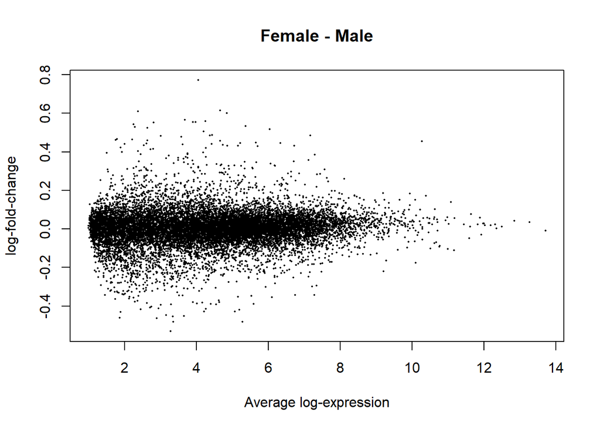

```r
plotMD(fit_sex)
```

## 6.2 Variável: Local de onde foi retirada a amostra

```r
levels(metadados$SAMPLE_SITE) = make.names(levels(metadados$SAMPLE_SITE))

design_site = model.matrix(~0+metadados$SAMPLE_SITE, data = y$samples)
colnames(design_site) = levels(metadados$SAMPLE_SITE)
head(design_site)
```

```
##                        Bone.Marrow.Aspirate Leukapheresis Peripheral.Blood
## aml_ohsu_2018_12.00023                    1             0                0
## aml_ohsu_2018_12.00051                    0             0                1
## aml_ohsu_2018_12.00066                    0             0                1
## aml_ohsu_2018_12.00150                    1             0                0
## aml_ohsu_2018_12.00211                    1             0                0
## aml_ohsu_2018_12.00258                    0             0                1
```

```r
contrast_site = makeContrasts( Bone_Leuk = Bone.Marrow.Aspirate - Leukapheresis,
                           Bone_Blood = Bone.Marrow.Aspirate - Peripheral.Blood,
                           Leuk_Blood = Leukapheresis - Peripheral.Blood,
                           levels=design_site)
fit_site = lmFit(logCPM, design_site)
fit_site = contrasts.fit(fit_site, contrast_site)
fit_site = eBayes(fit_site, trend=T)

topTable(fit = fit_site, genelist = row.names(logCPM))
```

```
##                     ProbeID  Bone_Leuk   Bone_Blood Leuk_Blood  AveExpr
## CHFR                   CHFR  1.1703909 -0.088467076 -1.2588580 6.107207
## STK24                 STK24  1.2781311 -0.039489014 -1.3176201 6.964352
## RP11-157G21.2 RP11-157G21.2 -1.0375163 -0.048357001  0.9891593 1.468112
## PROSER1             PROSER1  0.9169270  0.022947423 -0.8939796 6.632703
## RP4-740C4.6     RP4-740C4.6 -0.8532347  0.072359295  0.9255940 1.214843
## PROCR                 PROCR -0.9892011 -0.005105544  0.9840955 1.168010
## HNRNPLL             HNRNPLL  0.8265304 -0.452435811 -1.2789662 4.113143
## RP11-106M3.2   RP11-106M3.2 -0.7283293 -0.077265587  0.6510637 1.172205
## LINC01150         LINC01150 -1.0077240  0.237986587  1.2457106 1.971901
## DHRS7                 DHRS7 -0.5027810  0.104176372  0.6069574 6.079563
##                       F      P.Value    adj.P.Val
## CHFR          30.679847 3.209135e-13 4.622759e-09
## STK24         14.488221 7.969090e-07 5.340378e-03
## RP11-157G21.2 14.133753 1.112192e-06 5.340378e-03
## PROSER1        9.297535 1.104138e-04 3.976277e-01
## RP4-740C4.6    8.085553 3.547140e-04 9.534294e-01
## PROCR          7.791121 4.714188e-04 9.534294e-01
## HNRNPLL        7.682961 5.233891e-04 9.534294e-01
## RP11-106M3.2   7.328607 7.375125e-04 9.534294e-01
## LINC01150      7.284675 7.695749e-04 9.534294e-01
## DHRS7          7.151828 8.753041e-04 9.534294e-01
```

```r
summa.fit_site = decideTests(fit_site)
summary(summa.fit_site)
```

```
##        Bone_Leuk Bone_Blood Leuk_Blood
## Down           1          0          2
## NotSig     14402      14405      14402
## Up             2          0          1
```

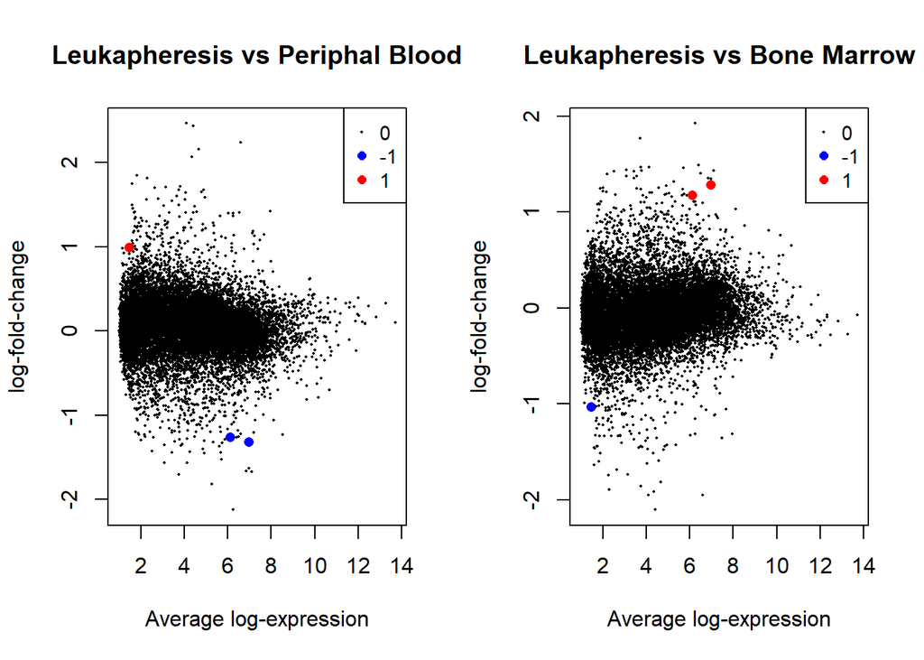

```r
par(mfrow= c(1, 2))
plotMD(fit_site,coef="Leuk_Blood",status=summa.fit_site[,"Leuk_Blood"], values = c(-1, 1), hl.col=c("blue","red"), main = "Leukapheresis vs Periphal Blood")
plotMD(fit_site,coef="Bone_Leuk",status=summa.fit_site[,"Bone_Leuk"], values = c(-1, 1), hl.col=c("blue","red"), main = "Leukapheresis vs Bone Marrow")
```

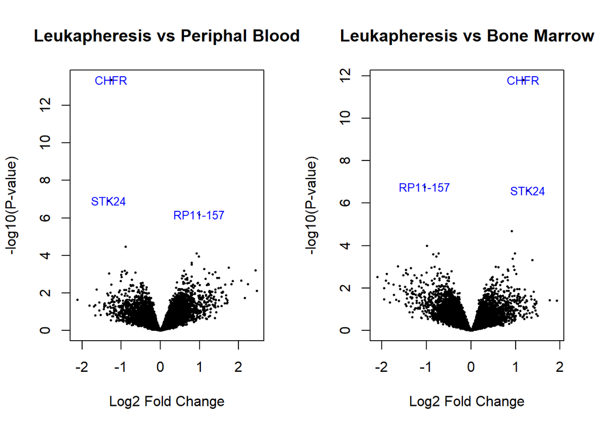

```r
par(mfrow= c(1, 2))
volcanoplot(fit_site,coef="Leuk_Blood",highlight=3,names=row.names(fit_site), main ="Leukapheresis vs Periphal Blood")
volcanoplot(fit_site,coef="Bone_Leuk",highlight=3,names=row.names(fit_site), main ="Leukapheresis vs Bone Marrow")
```

## 6.3 Variável: Sobrevivência do paciente

```r
table(metadados$OS_STATUS)
```

```
##
##              0:LIVING 1:DECEASED
##         43        170        238
```

```r
metadados$OS_STATUS <- gsub("0:LIVING", "Alive", metadados$OS_STATUS)
metadados$OS_STATUS <- gsub("1:DECEASED", "Deceased", metadados$OS_STATUS)
metadados$OS_STATUS <- as.character(metadados$OS_STATUS)
metadados$OS_STATUS <- ifelse(is.na(metadados$OS_STATUS) | nchar(metadados$OS_STATUS) == 0, "Unknown", metadados$OS_STATUS)
table(metadados$OS_STATUS)
```

```
##
##    Alive Deceased  Unknown
##      170      238       43
```

```r
metadados$OS_STATUS <- as.factor(metadados$OS_STATUS)

design_status = model.matrix(~0+metadados$OS_STATUS, data = y$samples)
colnames(design_status) = levels(metadados$OS_STATUS)


contrast_status = makeContrasts(Alive_Deceased = Alive - Deceased,
                                Alive_Unknown = Alive - Unknown,
                                Deceased_Unknown = Deceased - Unknown,
                                levels=design_status)

fit_status = lmFit(y$counts, design_status)
fit_status = contrasts.fit(fit_status, contrast_status)
fit_status = eBayes(fit_status, trend=T)
topTable(fit = fit_status, genelist = y$genes)
```

```
##                       genes Alive_Deceased Alive_Unknown Deceased_Unknown
## MAGIX                 MAGIX    -0.13764167  -0.007091497        0.1305502
## INSIG1               INSIG1     0.01590885   0.451799767        0.4358909
## ALKBH5               ALKBH5    -0.08818995   0.144183882        0.2323738
## C6orf62             C6orf62    -0.07910215   0.130506196        0.2096083
## RP13-270P17.3 RP13-270P17.3    -0.12225891   0.132091349        0.2543503
## C7orf60             C7orf60     0.02766925   0.313997891        0.2863286
## MAP4K4               MAP4K4     0.18507125   0.335247493        0.1501762
## NFYC-AS1           NFYC-AS1    -0.14027841   0.025715111        0.1659935
## RP5-1007M22.2 RP5-1007M22.2    -0.06795016   0.310605190        0.3785554
## PPM1H                 PPM1H    -0.47156015  -0.082596724        0.3889634
##                AveExpr        F      P.Value adj.P.Val
## MAGIX         1.246553 8.569332 0.0002224574 0.9801777
## INSIG1        6.123672 7.509806 0.0006188408 0.9801777
## ALKBH5        6.711053 7.321886 0.0007423300 0.9801777
## C6orf62       7.921624 7.030997 0.0009840975 0.9801777
## RP13-270P17.3 1.837685 6.944766 0.0010699515 0.9801777
## C7orf60       4.071187 6.912527 0.0011039486 0.9801777
## MAP4K4        7.784796 6.790906 0.0012422615 0.9801777
## NFYC-AS1      1.242891 6.779976 0.0012555128 0.9801777
## RP5-1007M22.2 2.213703 6.718888 0.0013322375 0.9801777
## PPM1H         4.055705 6.689116 0.0013713200 0.9801777
```

```r
summa.fit_status = decideTests(fit_status)
summary(summa.fit_status)
```

```
##        Alive_Deceased Alive_Unknown Deceased_Unknown
## Down                0             0                0
## NotSig          14405         14405            14405
## Up                  0             0                0
```

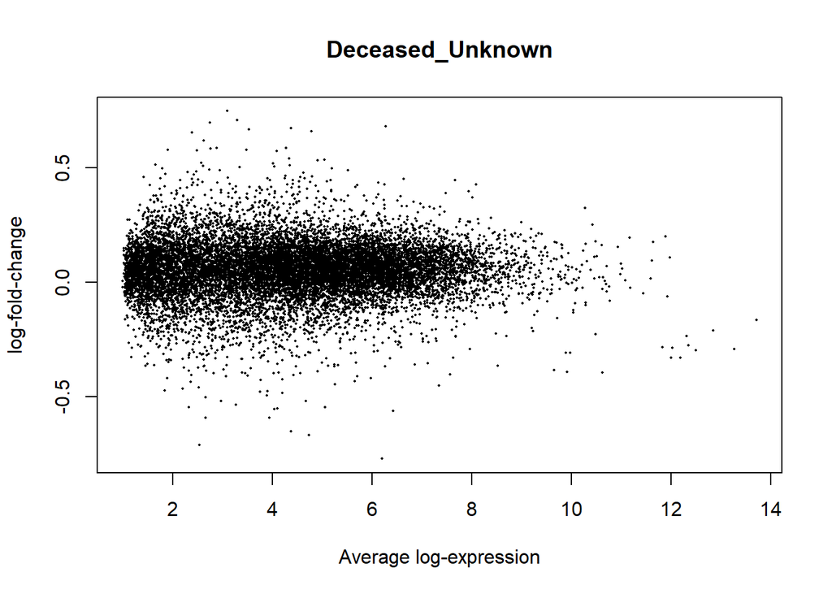

```r
plotMD(fit_status)
```

## 6.4 Variável: Estado dos tratamentos cumulativos

```r
table(metadados$CUMULATIVE_TREATMENT_STAGE_COUNT)
```

```
##
##   0   1   2   3   4   5   6   7   8
##  22 100 118 108  69  25   7   1   1
```

```r
metadados$CUMULATIVE_TREATMENT_STAGE_COUNT <- gsub(0, "Zero", metadados$CUMULATIVE_TREATMENT_STAGE_COUNT)
metadados$CUMULATIVE_TREATMENT_STAGE_COUNT <- gsub(1, "Um", metadados$CUMULATIVE_TREATMENT_STAGE_COUNT)
metadados$CUMULATIVE_TREATMENT_STAGE_COUNT <- gsub(2, "Dois", metadados$CUMULATIVE_TREATMENT_STAGE_COUNT)
metadados$CUMULATIVE_TREATMENT_STAGE_COUNT <- gsub(3, "Três", metadados$CUMULATIVE_TREATMENT_STAGE_COUNT)
metadados$CUMULATIVE_TREATMENT_STAGE_COUNT <- gsub(4, "Quatro", metadados$CUMULATIVE_TREATMENT_STAGE_COUNT)
metadados$CUMULATIVE_TREATMENT_STAGE_COUNT <- gsub(5, "Cinco", metadados$CUMULATIVE_TREATMENT_STAGE_COUNT)
metadados$CUMULATIVE_TREATMENT_STAGE_COUNT <- gsub(6, "Seis", metadados$CUMULATIVE_TREATMENT_STAGE_COUNT)
metadados$CUMULATIVE_TREATMENT_STAGE_COUNT <- gsub(7, "Sete", metadados$CUMULATIVE_TREATMENT_STAGE_COUNT)
metadados$CUMULATIVE_TREATMENT_STAGE_COUNT <- gsub(8, "Oito", metadados$CUMULATIVE_TREATMENT_STAGE_COUNT)

metadados$CUMULATIVE_TREATMENT_STAGE_COUNT = as.factor(metadados$CUMULATIVE_TREATMENT_STAGE_COUNT)
table(metadados$CUMULATIVE_TREATMENT_STAGE_COUNT)
```

```
##
##  Cinco   Dois   Oito Quatro   Seis   Sete   Três     Um   Zero
##     25    118      1     69      7      1    108    100     22
```

```r
design_stage = model.matrix(~0+metadados$CUMULATIVE_TREATMENT_STAGE_COUNT, data = y$samples)
colnames(design_stage) = levels(metadados$CUMULATIVE_TREATMENT_STAGE_COUNT)
head(design_stage)
```

```
##                        Cinco Dois Oito Quatro Seis Sete Três Um Zero
## aml_ohsu_2018_12.00023     0    1    0      0    0    0    0  0    0
## aml_ohsu_2018_12.00051     0    0    0      0    0    0    0  0    1
## aml_ohsu_2018_12.00066     0    1    0      0    0    0    0  0    0
## aml_ohsu_2018_12.00150     0    1    0      0    0    0    0  0    0
## aml_ohsu_2018_12.00211     0    0    0      0    0    0    0  1    0
## aml_ohsu_2018_12.00258     1    0    0      0    0    0    0  0    0
```

```r
contrast_stage = makeContrasts('0_1'= Zero - Um, '0_2'= Zero - Dois, '0_3'= Zero - Três, '0_4'= Zero - Quatro, '0_5'= Zero - Cinco, '0_6' = Zero - Seis, '0_7' = Zero - Sete, '0_8' = Zero - Oito, '1_2'= Um - Dois, '1_3'= Um - Três, '1_4'= Um - Quatro, '1_5'= Um - Cinco,
'1_6' = Um - Seis, '1_7' = Um - Sete, '1_8' = Um - Oito, '2_3'= Dois - Três, '2_4'= Dois - Quatro, '2_5'= Dois - Cinco, '2_6' = Dois - Seis, '2_7' = Dois - Sete, '2_8' = Dois - Oito, '3_4'= Três - Quatro, '3_5'= Três - Cinco, '3_6' = Três - Seis, '3_7' = Três - Sete, '3_8' = Três - Oito, '4_5'= Quatro - Cinco, '4_6' = Quatro - Seis, '4_7' = Quatro - Sete, '4_8' = Quatro - Oito, '5_6' = Cinco - Seis, '5_7' = Cinco - Sete, '5_8' = Cinco - Oito,
'6_7' = Seis - Sete, '6_8' = Seis - Oito, '7_8' = Sete - Oito, levels=design_stage)

fit_stage = lmFit(y$counts, design_stage)
fit_stage = contrasts.fit(fit_stage, contrast_stage)
fit_stage = eBayes(fit_stage, trend=T)
topTable(fit = fit_stage, genelist = y$genes)
```

```
##                     genes       X0_1      X0_2         X0_3      X0_4
## CTGLF12P         CTGLF12P 0.07254338 0.2336207  0.318688833 0.2486750
## DNAJC15           DNAJC15 0.11327379 0.2740446  0.355227279 0.1921762
## RPSAP54           RPSAP54 0.49032446 0.5451956  0.135523595 0.5758013
## RPS12               RPS12 0.35059428 0.3510331 -0.098212830 0.2992845
## RP11-159H3.1 RP11-159H3.1 0.28165811 0.3497358 -0.023857089 0.3185922
## MIR4426           MIR4426 0.22606655 0.2308624 -0.174855487 0.1800200
## RPL23               RPL23 0.22781341 0.2989472  0.008245019 0.2739995
## RP3-486I3.4   RP3-486I3.4 0.30055964 0.3608883 -0.068480225 0.2739737
## RPSAP9             RPSAP9 0.17078586 0.2022215 -0.045212358 0.2372137
## ATF7IP2           ATF7IP2 0.13487037 0.3133909  0.040191090 0.2876102
##                    X0_5       X0_6        X0_7       X0_8         X1_2
## CTGLF12P     -0.2742692 0.12796675 -3.47107991 -0.4839897 0.1610772837
## DNAJC15       0.4111642 0.24754620  0.29121423  3.9194611 0.1607707889
## RPSAP54       0.7018314 0.44268706  0.96217932  1.1724359 0.0548711298
## RPS12         0.3447967 0.52001782  0.12781003  1.6431953 0.0004388593
## RP11-159H3.1  0.2523300 0.16457143  0.05112532  1.4397613 0.0680777022
## MIR4426       0.2235005 0.12782656  0.10171955  1.1992383 0.0047958467
## RPL23         0.3638091 0.02781763  0.79606286  1.1288257 0.0711338304
## RP3-486I3.4   0.3056643 0.23105788  0.45451963  0.8506437 0.0603286690
## RPSAP9        0.2776104 0.16074623  0.17505872  0.7008733 0.0314356659
## ATF7IP2       0.1001442 0.54998028  4.26702945  1.7040937 0.1785205465
##                     X1_3        X1_4         X1_5        X1_6         X1_7
## CTGLF12P      0.24614545  0.17613163 -0.346812597  0.05542337 -3.543623295
## DNAJC15       0.24195349  0.07890245  0.297890360  0.13427240  0.177940436
## RPSAP54      -0.35480086  0.08547682  0.211506933 -0.04763739  0.471854866
## RPS12        -0.44880711 -0.05130976 -0.005797602  0.16942354 -0.222784255
## RP11-159H3.1 -0.30551520  0.03693409 -0.029328089 -0.11708668 -0.230532786
## MIR4426      -0.40092204 -0.04604657 -0.002566018 -0.09823999 -0.124346997
## RPL23        -0.21956839  0.04618609  0.135995666 -0.19999577  0.568249447
## RP3-486I3.4  -0.36903986 -0.02658595  0.005104712 -0.06950175  0.153959997
## RPSAP9       -0.21599822  0.06642788  0.106824576 -0.01003962  0.004272865
## ATF7IP2      -0.09467928  0.15273984 -0.034726141  0.41510991  4.132159074
##                    X1_8        X2_3        X2_4         X2_5        X2_6
## CTGLF12P     -0.5565331  0.08506817  0.01505434 -0.507889881 -0.10565391
## DNAJC15       3.8061873  0.08118270 -0.08186834  0.137119571 -0.02649838
## RPSAP54       0.6821114 -0.40967199  0.03060569  0.156635803 -0.10250852
## RPS12         1.2926011 -0.44924597 -0.05174862 -0.006236462  0.16898468
## RP11-159H3.1  1.1581032 -0.37359290 -0.03114362 -0.097405792 -0.18516438
## MIR4426       0.9731718 -0.40571788 -0.05084242 -0.007361865 -0.10303584
```

[output cut: 33 more lines]

```
## RPL23         0.8548262 -0.33599144  0.4322538  0.7650167  0.76824522
## RP3-486I3.4   0.5766700 -0.07460646  0.1488553  0.5449793  0.22346175
## RPSAP9        0.4636596 -0.11686420 -0.1025517  0.4232629  0.01431249
## ATF7IP2       1.4164834  0.44983605  4.1668852  1.6039494  3.71704916
##                    X6_8       X7_8  AveExpr        F      P.Value adj.P.Val
## CTGLF12P     -0.6119565  2.9870902 1.282326 4.601633 2.071354e-05 0.2945600
## DNAJC15       3.6719149  3.6282469 4.498787 4.383750 4.089691e-05 0.2945600
## RPSAP54       0.7297488  0.2102566 3.135275 4.112998 9.476170e-05 0.3269925
## RPS12         1.1231775  1.5153853 8.008603 4.106466 9.669470e-05 0.3269925
## RP11-159H3.1  1.2751899  1.3886360 2.025103 4.040408 1.185777e-04 0.3269925
## MIR4426       1.0714118  1.0975188 2.842776 3.980620 1.425729e-04 0.3269925
## RPL23         1.1010081  0.3327629 8.614089 3.945391 1.588995e-04 0.3269925
## RP3-486I3.4   0.6195858  0.3961241 4.375741 3.819567 2.337923e-04 0.4209723
## RPSAP9        0.5401271  0.5258146 1.913578 3.759823 2.806674e-04 0.4492238
## ATF7IP2       1.1541134 -2.5629358 4.954410 3.656571 3.845135e-04 0.4923229
```

```r
summa.fit_stage = decideTests(fit_stage)
summary(summa.fit_stage)
```

```
##          0_1   0_2   0_3   0_4   0_5   0_6   0_7   0_8   1_2   1_3   1_4   1_5
## Down       0     0     0     0     0     0     0     0     0     0     0     0
## NotSig 14405 14405 14405 14405 14405 14405 14405 14403 14405 14405 14405 14405
## Up         0     0     0     0     0     0     0     2     0     0     0     0
##          1_6   1_7   1_8   2_3   2_4   2_5   2_6   2_7   2_8   3_4   3_5   3_6
## Down       0     0     0    54     0     0     0     0     0     1     0     0
## NotSig 14405 14405 14403 14351 14405 14405 14405 14405 14401 14404 14405 14405
## Up         0     0     2     0     0     0     0     0     4     0     0     0
##          3_7   3_8   4_5   4_6   4_7   4_8   5_6   5_7   5_8   6_7   6_8   7_8
## Down       2     0     0     0     0     0     0     0     0     0     0     0
## NotSig 14402 14402 14405 14405 14405 14400 14405 14405 14403 14405 14401 14405
## Up         1     3     0     0     0     5     0     0     2     0     4     0
```

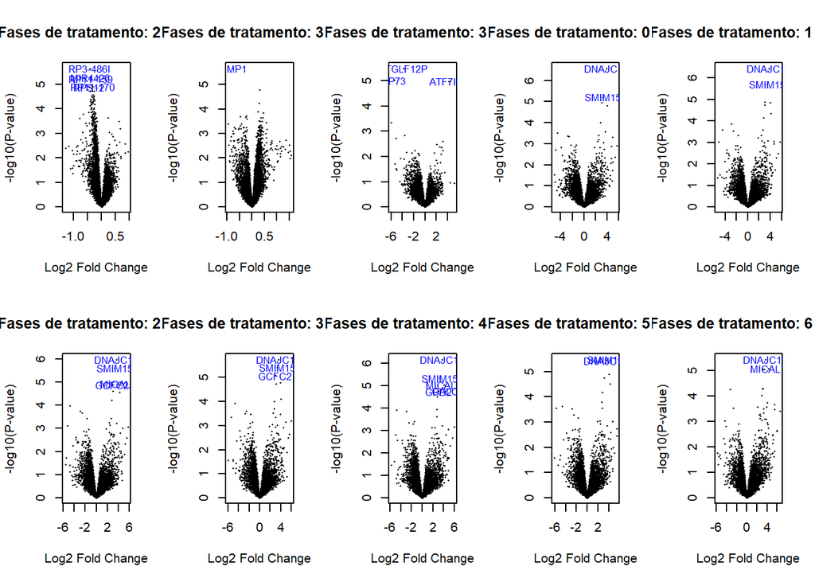

```r
par(mfrow=c(2, 5))
volcanoplot(fit_stage,coef="2_3",highlight=5, names=row.names(fit_stage), main ="Fases de tratamento: 2 vs 3")
volcanoplot(fit_stage,coef="3_4",highlight=1, names=row.names(fit_stage), main ="Fases de tratamento: 3 vs 4")
volcanoplot(fit_stage,coef="3_7",highlight=3, names=row.names(fit_stage), main ="Fases de tratamento: 3 vs 7")
volcanoplot(fit_stage,coef="0_8",highlight=2, names=row.names(fit_stage), main ="Fases de tratamento: 0 vs 8")
volcanoplot(fit_stage,coef="1_8",highlight=2, names=row.names(fit_stage), main ="Fases de tratamento: 1 vs 8")
volcanoplot(fit_stage,coef="2_8",highlight=4, names=row.names(fit_stage), main ="Fases de tratamento: 2 vs 8")
volcanoplot(fit_stage,coef="3_8",highlight=3, names=row.names(fit_stage), main ="Fases de tratamento: 3 vs 8")
volcanoplot(fit_stage,coef="4_8",highlight=5, names=row.names(fit_stage), main ="Fases de tratamento: 4 vs 8")
volcanoplot(fit_stage,coef="5_8",highlight=2, names=row.names(fit_stage), main ="Fases de tratamento: 5 vs 8")
volcanoplot(fit_stage,coef="6_8",highlight=2, names=row.names(fit_stage), main ="Fases de tratamento: 6 vs 8")
```

## 6.5 Variável: Nº de tratamentos cumulativos

```r
table(metadados$CUMULATIVE_TREATMENT_TYPE_COUNT)
```

```
##
##   0   1   2   3   4   5
##  22 227 162  35   4   1
```

```r
metadados$CUMULATIVE_TREATMENT_TYPE_COUNT <- gsub(0, "Zero", metadados$CUMULATIVE_TREATMENT_TYPE_COUNT)
metadados$CUMULATIVE_TREATMENT_TYPE_COUNT <- gsub(1, "Um", metadados$CUMULATIVE_TREATMENT_TYPE_COUNT)
metadados$CUMULATIVE_TREATMENT_TYPE_COUNT <- gsub(2, "Dois", metadados$CUMULATIVE_TREATMENT_TYPE_COUNT)
metadados$CUMULATIVE_TREATMENT_TYPE_COUNT <- gsub(3, "Três", metadados$CUMULATIVE_TREATMENT_TYPE_COUNT)
metadados$CUMULATIVE_TREATMENT_TYPE_COUNT <- gsub(4, "Quatro", metadados$CUMULATIVE_TREATMENT_TYPE_COUNT)
metadados$CUMULATIVE_TREATMENT_TYPE_COUNT <- gsub(5, "Cinco", metadados$CUMULATIVE_TREATMENT_TYPE_COUNT)


metadados$CUMULATIVE_TREATMENT_TYPE_COUNT = as.factor(metadados$CUMULATIVE_TREATMENT_TYPE_COUNT)
table(metadados$CUMULATIVE_TREATMENT_TYPE_COUNT)
```

```
##
##  Cinco   Dois Quatro   Três     Um   Zero
##      1    162      4     35    227     22
```

```r
design_ntreat = model.matrix(~0+metadados$CUMULATIVE_TREATMENT_TYPE_COUNT, data = y$samples)
colnames(design_ntreat) = levels(metadados$CUMULATIVE_TREATMENT_TYPE_COUNT)
head(design_ntreat)
```

```
##                        Cinco Dois Quatro Três Um Zero
## aml_ohsu_2018_12.00023     0    0      0    0  1    0
## aml_ohsu_2018_12.00051     0    0      0    0  0    1
## aml_ohsu_2018_12.00066     0    1      0    0  0    0
## aml_ohsu_2018_12.00150     0    0      0    0  1    0
## aml_ohsu_2018_12.00211     0    0      0    0  1    0
## aml_ohsu_2018_12.00258     0    0      0    1  0    0
```

```r
contrast_ntreat = makeContrasts('0_1'= Zero - Um, '0_2'= Zero - Dois, '0_3'= Zero - Três, '0_4'= Zero - Quatro, '0_5'= Zero - Cinco,
                                '1_2'= Um - Dois, '1_3'= Um - Três, '1_4'= Um - Quatro, '1_5'= Um - Cinco,
                                '2_3'= Dois - Três, '2_4'= Dois - Quatro, '2_5'= Dois - Cinco,
                                '3_4'= Três - Quatro, '3_5'= Três - Cinco,
                                '4_5'= Quatro - Cinco,
                                levels=design_ntreat)

fit_ntreat = lmFit(y$counts, design_ntreat)
fit_ntreat = contrasts.fit(fit_ntreat, contrast_ntreat)
fit_ntreat = eBayes(fit_ntreat, trend=T)
topTable(fit = fit_ntreat, genelist = y$genes)
```

```
##           genes        X0_1        X0_2         X0_3        X0_4     X0_5
## DNAJC15 DNAJC15  0.22191755  0.33107816  0.004048902  0.86020722 3.919461
## ZNF555   ZNF555  0.14512748  0.20260539 -0.086448573  2.03934817 2.599602
## CMTM7     CMTM7 -0.24843801 -0.29978545 -0.023835152  0.42197641 2.516411
## GALC       GALC -0.40211141 -0.44723942 -0.619635934  0.51502158 3.728885
## SMIM15   SMIM15 -0.07008345 -0.05288745 -0.090825315  0.43282424 3.308541
## GPD2       GPD2 -0.16900336 -0.30137332 -0.254750791 -0.06085417 2.839671
## ZNF518B ZNF518B -0.16707261  0.11732222 -0.249076238  0.48499877 2.666987
## MICAL1   MICAL1  0.03840724 -0.02067233  0.107403551  0.79034199 4.006867
## ZFP90     ZFP90 -0.11927397 -0.14948470 -0.338975413  0.68765657 2.580930
## SPINT2   SPINT2 -0.30034249 -0.20592816 -0.317864754  2.04272827 3.682292
##                X1_2        X1_3      X1_4     X1_5        X2_3      X2_4
## DNAJC15  0.10916061 -0.21786865 0.6382897 3.697544 -0.32702926 0.5291291
## ZNF555   0.05747790 -0.23157606 1.8942207 2.454474 -0.28905396 1.8367428
## CMTM7   -0.05134744  0.22460286 0.6704144 2.764849  0.27595030 0.7217619
## GALC    -0.04512801 -0.21752452 0.9171330 4.130997 -0.17239651 0.9622610
## SMIM15   0.01719600 -0.02074187 0.5029077 3.378624 -0.03793786 0.4857117
## GPD2    -0.13236996 -0.08574743 0.1081492 3.008674  0.04662253 0.2405192
## ZNF518B  0.28439483 -0.08200363 0.6520714 2.834059 -0.36639846 0.3676766
## MICAL1  -0.05907957  0.06899632 0.7519348 3.968460  0.12807589 0.8110143
## ZFP90   -0.03021074 -0.21970145 0.8069305 2.700204 -0.18949071 0.8371413
## SPINT2   0.09441433 -0.01752226 2.3430708 3.982634 -0.11193659 2.2486564
##             X2_5      X3_4     X3_5      X4_5  AveExpr        F      P.Value
## DNAJC15 3.588383 0.8561583 3.915412 3.0592539 4.498787 7.399793 1.105360e-06
## ZNF555  2.396996 2.1257967 2.686050 0.5602534 2.845066 5.841169 3.055220e-05
## CMTM7   2.816196 0.4458116 2.540246 2.0944345 5.690886 5.468215 6.736754e-05
## GALC    4.176125 1.1346575 4.348521 3.2138639 5.441850 5.267473 1.030027e-04
## SMIM15  3.361428 0.5236496 3.399366 2.8757163 4.757147 4.990830 1.846474e-04
## GPD2    3.141044 0.1938966 3.094422 2.9005250 5.602538 4.929257 2.102091e-04
## ZNF518B 2.549664 0.7340750 2.916063 2.1819878 4.436438 4.782521 2.861911e-04
## MICAL1  4.027540 0.6829384 3.899464 3.2165254 7.639891 4.719442 3.267215e-04
## ZFP90   2.730415 1.0266320 2.919905 1.8932734 4.540383 4.508316 5.085020e-04
## SPINT2  3.888220 2.3605930 4.000156 1.6395633 5.428976 4.382365 6.615671e-04
##          adj.P.Val
## DNAJC15 0.01592271
## ZNF555  0.22005225
## CMTM7   0.32347647
## GALC    0.37093865
## SMIM15  0.50467697
## GPD2    0.50467697
## ZNF518B 0.58830292
## MICAL1  0.58830292
## ZFP90   0.81388563
## SPINT2  0.86765786
```

```r
summa.fit_ntreat = decideTests(fit_ntreat)
summary(summa.fit_ntreat)
```

```
##          0_1   0_2   0_3   0_4   0_5   1_2   1_3   1_4   1_5   2_3   2_4   2_5
## Down       0     0     0     0     0     0     0     0     0     0     0     0
## NotSig 14405 14405 14405 14405 14403 14405 14405 14405 14401 14405 14405 14400
## Up         0     0     0     0     2     0     0     0     4     0     0     5
##          3_4   3_5   4_5
## Down       0     0     0
## NotSig 14405 14399 14405
## Up         0     6     0
```

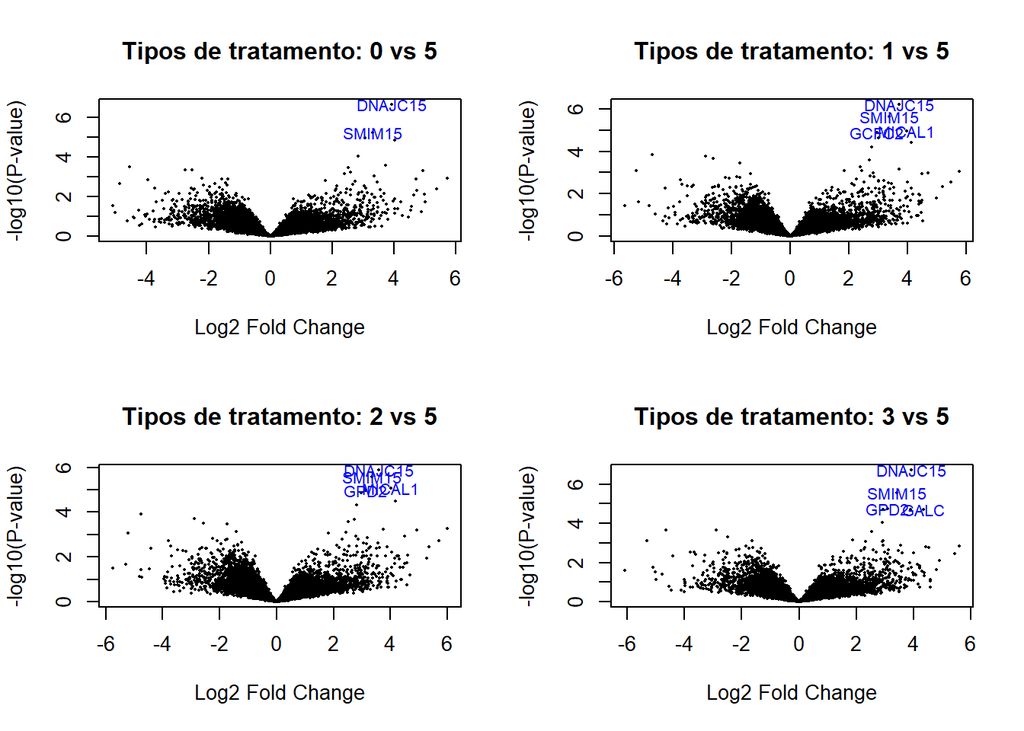

```r
par(mfrow=c(2, 2))
volcanoplot(fit_ntreat,coef="0_5",highlight=2, names=row.names(fit_ntreat), main ="Tipos de tratamento: 0 vs 5")
volcanoplot(fit_ntreat,coef="1_5",highlight=4, names=row.names(fit_ntreat), main ="Tipos de tratamento: 1 vs 5")
volcanoplot(fit_ntreat,coef="2_5",highlight=4, names=row.names(fit_ntreat), main ="Tipos de tratamento: 2 vs 5")
volcanoplot(fit_ntreat,coef="3_5",highlight=4, names=row.names(fit_ntreat), main ="Tipos de tratamento: 3 vs 5")
```

# 7 **Análise não supervisionada**

Com o objetivo de indentificar possíveis padrões ou agrupamentos nos dados de expressão diferencial que nos permitam de alguma forma perver características das amostras ou dos pacientes, especificamente a resposta deste ao tratamento, começamos por uma análise não supervisionada como o clustering hierárquico ou k-means.

Dada a expressão diferencial analisada anteriormente e os resultados obtidos num artigo anterior[^4], optámos por verificar se há a formação de clusteres associados ao sexo e à sobrevivência dos paicentes.

## 7.1 Clustering de genes de acordo com o sexo dos pacientes

```r
# Preparação dos dados:
DADOS = t(logCPM) #Transpor os dados
metadados$SEX = as.factor(metadados$SEX)
logCPM_metadados = cbind(DADOS, metadados)

#Clustering
logCPM_metadados.sc = scale(logCPM_metadados[,1:14405])
dist.logCPM_metadados = dist(logCPM_metadados.sc, method = "manhattan")
cl.logCPM_metadados = hclust(dist.logCPM_metadados, method = "average")
my.plot.hc = function(hclust, lab = 1:length(hclust$order), lab.col = rep(1, length(hclust$order)), hang = 0.1, ...)

my.plot.hc(cl.logCPM_metadados, lab.col = as.integer(logCPM_metadados$SEX)+1, cex = 0.6)
```

```r
logCPM_matrix <- as.matrix(logCPM)

class(logCPM_matrix) <- 'numeric'
max_logCPM_matrix <- apply(logCPM_matrix, 1, max)
min_logCPM_matrix <- apply(logCPM_matrix, 1, min)
vl <-max_logCPM_matrix/min_logCPM_matrix > 2
logCPM_matrix <-logCPM_matrix[vl, ]
logCPM_matrix <-na.exclude(logCPM_matrix)
```

```r
expressao <- gsub("\\..*", "", rownames(logCPM_matrix))
rownames(logCPM_matrix) <- expressao
rownames(logCPM_matrix) <- make.names(rownames(logCPM_matrix), unique = TRUE)

test <- rowttests(logCPM_matrix)
ranking <- order(test$p.value)
p_value <- ranking[1:50]
genes_top50 = logCPM_matrix[p_value, ]
```

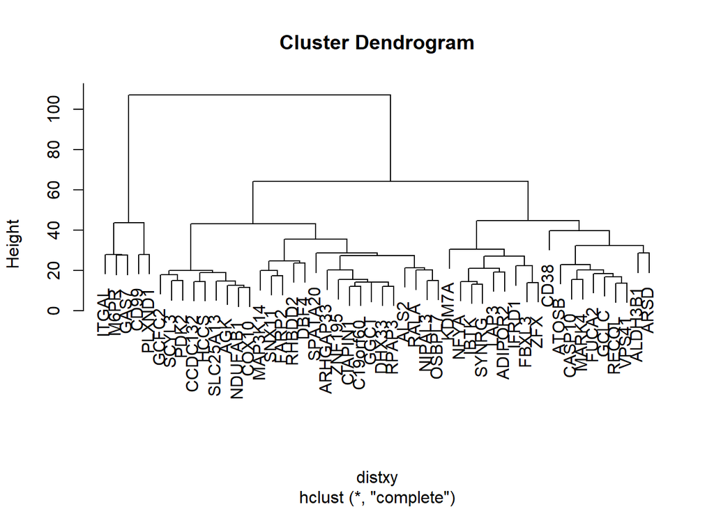

```r
distxy <- dist(genes_top50, method = 'euclidean')
hc = hclust(distxy, method = 'complete')
plot(hc)
```

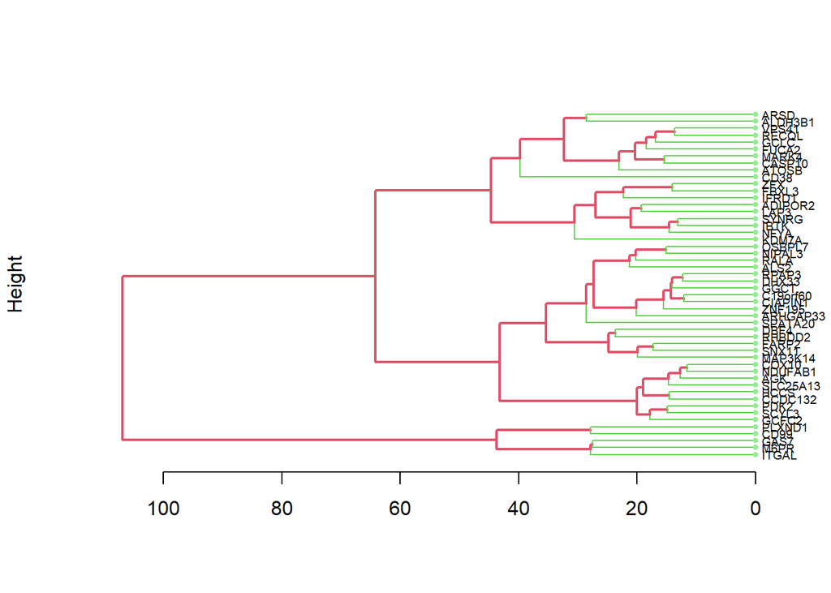

```r
hcd <- as.dendrogram(hc)
nodePar <- list(lab.cex = 0.6, pch = c(NA,20), cex = 0.8, col = "lightgreen")
plot(hcd, ylab = "Height", nodePar = nodePar, horiz = TRUE, edgePar = list(col = 2:3, lwd = 2:1))
```

Através do clustering hierárquico é possível ver que há uma relação entre os genes sendo possível agrupá-los em alguns clusteres.

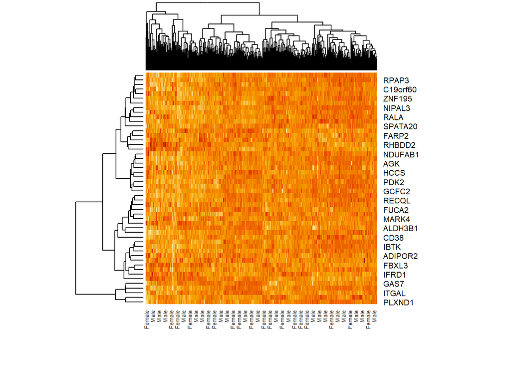

```r
heatmap(genes_top50, labCol = sort(metadados$SEX))
```

O heatmap não revela nenhum padrão de expressão génica entre homens e mulheres, não havendo o agrupamento de genes em dois clusteres associados ao sexo.

## 7.2 Clustering de genes de acordo com a sobrevivência dos pacientes

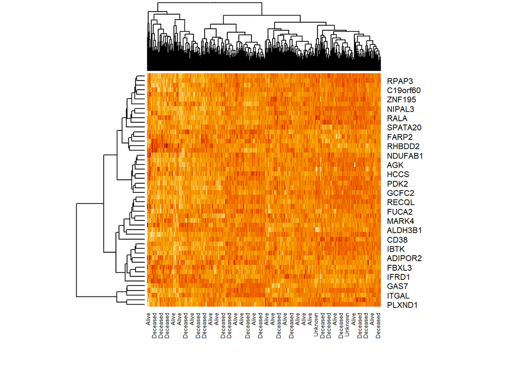

```r
heatmap(genes_top50, labCol = sort(metadados$OS_STATUS))
```

Através da análise do heatmap não se consegue distinguir padrões ou clusteres para a sobrevivência dos pacientes baseado na expressão génica.

```r
set.seed(123)
logCPM_matrix <- logCPM_matrix[1:length(metadados$OS_STATUS)]
centers <- cut(logCPM_matrix, breaks = 4)
centers_factor <- factor(centers)
live_factor <- factor(metadados$OS_STATUS)

levels(centers_factor) <- c("Cluster 1", "Cluster 2", "Cluster 3", "Cluster 4")

table <- table(centers_factor, live_factor)
print(table)
```

```
##               live_factor
## centers_factor Alive Deceased Unknown
##      Cluster 1    32       61       4
##      Cluster 2    94      132      31
##      Cluster 3    41       40       8
##      Cluster 4     3        5       0
```

# 8 **Redução da dimensionalidade**

A análise não supervisionada será aplicada nos dados expressão genética filtrados para os genes que apenas tenham pelo menos metade dos pacientes com CPM superior a 1 fossem analisados, e normalizado (`logCPM`).

## 8.1 Processamento dos dados:

```r
# União dos dados com metadados relevantes para análises:
metadados_select = metadados[,c(8, 30)] # Seleciona o SAMPLE_SITE e o OS_STATUS.
merged_df <- merge(DADOS, metadados_select, by = "row.names")
row.names(merged_df) <- merged_df$Row.names
merged_df = merged_df[, -1]


# União com os outros metadados do sample_data_rna: "CUMULATIVE_TREATMENT_STAGE_COUNT" e "CUMULATIVE_TREATMENT_TYPE_COUNT":
metadados_counts = sample_data_rna[ , c("CUMULATIVE_TREATMENT_STAGE_COUNT", "CUMULATIVE_TREATMENT_TYPE_COUNT")]
merged_df <- merge(merged_df, metadados_counts, by = "row.names")
row.names(merged_df) <- merged_df$Row.names
merged_df = merged_df[, -1]
```

## 8.2 Determinação das métricas (PCA)

```r
# Formulação do PCA dos dados:
dados_pca = merged_df[, -c(14406:14409)]
pca_result <- prcomp(dados_pca, scale = F)

summary(pca_result)
```

[output not shown]

[output cut: 206 more lines]

```
## Standard deviation     1.14649 1.14219 1.13794 1.13290 1.11534 1.10760 1.1018
## Proportion of Variance 0.00011 0.00011 0.00011 0.00011 0.00011 0.00011 0.0001
## Cumulative Proportion  0.99786 0.99797 0.99808 0.99819 0.99830 0.99840 0.9985
##                         PC432  PC433  PC434  PC435   PC436   PC437   PC438
## Standard deviation     1.0940 1.0830 1.0721 1.0539 1.05038 1.04168 1.02743
## Proportion of Variance 0.0001 0.0001 0.0001 0.0001 0.00009 0.00009 0.00009
## Cumulative Proportion  0.9986 0.9987 0.9988 0.9989 0.99900 0.99909 0.99919
##                          PC439   PC440   PC441   PC442   PC443   PC444   PC445
## Standard deviation     1.01284 1.00126 0.98216 0.96153 0.95062 0.91552 0.89739
## Proportion of Variance 0.00009 0.00009 0.00008 0.00008 0.00008 0.00007 0.00007
## Cumulative Proportion  0.99927 0.99936 0.99944 0.99952 0.99960 0.99967 0.99974
##                          PC446   PC447   PC448   PC449   PC450    PC451
## Standard deviation     0.87688 0.85072 0.76327 0.69931 0.66498 3.11e-14
## Proportion of Variance 0.00007 0.00006 0.00005 0.00004 0.00004 0.00e+00
## Cumulative Proportion  0.99981 0.99987 0.99992 0.99996 1.00000 1.00e+00
```

[figure not shown]

```r
biplot(pca_result)
```

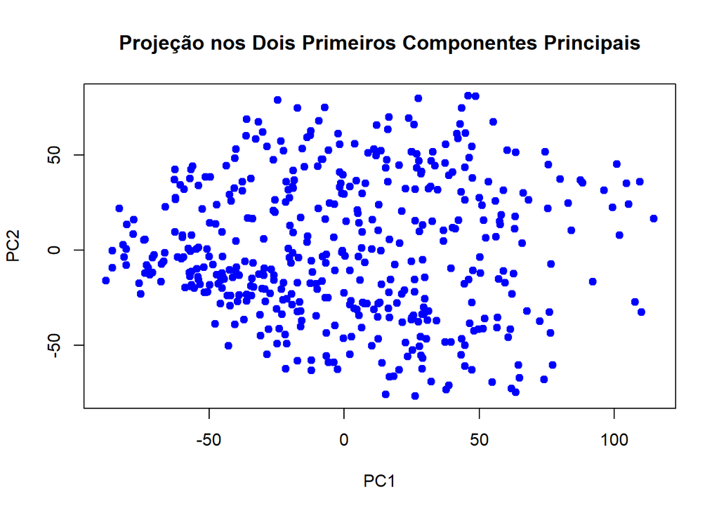

```r
#Visualizar a distribuição dos pontos no PC1 e o PC2:
pca_data <- as.data.frame(pca_result$x[, 1:2])
plot(pca_data$PC1, pca_data$PC2,
     main = "Projeção nos Dois Primeiros Componentes Principais",
     xlab = "PC1",
     ylab = "PC2",
     pch = 19,
     col = "blue")
```

```r
# determinação de qunatos PCAs explicam 90% dos dados:
prop_var <- summary(pca_result)$importance["Proportion of Variance",]
cumulative_prop_var <- cumsum(prop_var)
n_components_90 <- which(cumulative_prop_var >= 0.9)[1]
n_components_90
```

```
## PC132
##   132
```

A análise dos dados a partir de PCA permitiu concluir que os primeiros 132 componentes principais explicam 90% da variabilidade dos dados, como esse número é consideravelmente inferior ao número inicial de genes (14405), é possível fazer uma redução da dimensão sem perder muita informação. Posteriormente, essa informação pode ser usada para seleccionar os genes que mais contribuem para a variabilidade dos dados de expressão e identificar os processos biológicos significativos.

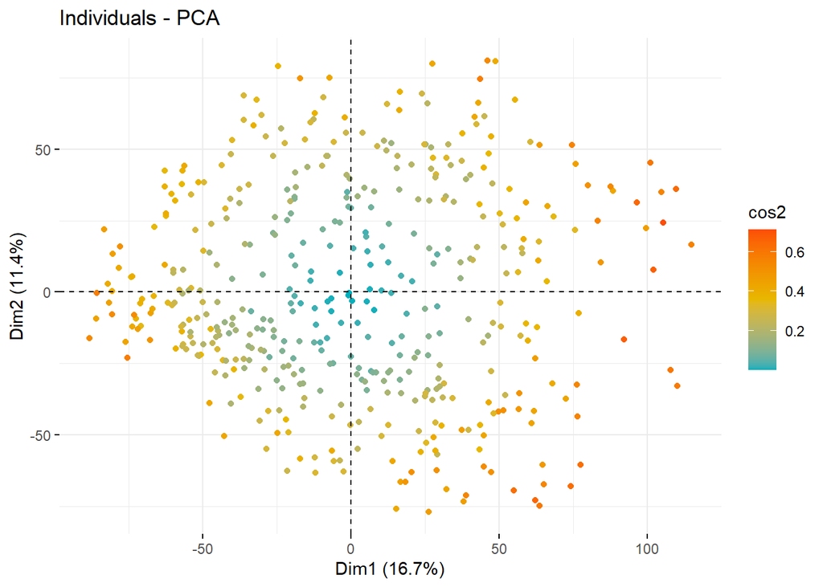

```r
# Análise da qualidade das variáveis individuais nos dois primeiros componentes principais
fviz_famd_ind(pca_result, geom = c("point"), col.ind = "cos2", gradient.cols = c("#00AFBB", "#E7B800", "#FC4E07"), palette = "rainbow", addEllipses = FALSE, ellipse.type = "confidence",ggtheme = theme_minimal(), repel = TRUE, labels = F)
```

No gráfico `Individual-PCA` é possível observar a qualidade da representação (“cos2”) das variáveis individuais nos dois primeiros componentes principais (que em conjunto explicam 28,1% da variabilidade dos dados), assim nota-se que as variáveis mais próximas de zero, apresentam uma variação menos explicada do que as mais distantes (coloração alaranjada).

### 8.2.1 Análise de diferentes metadados e suas distribuições nos PCAs

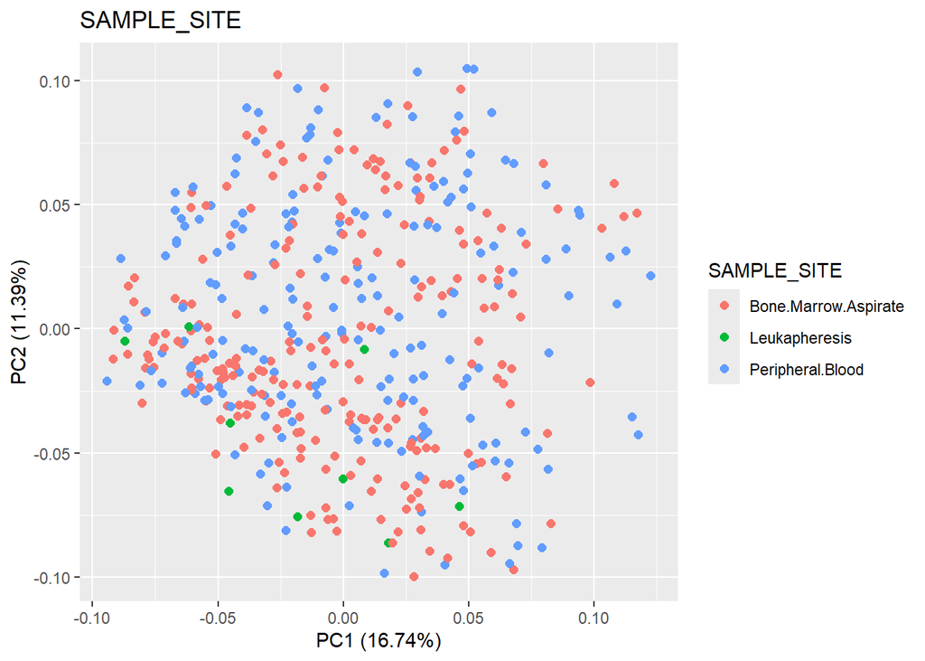

```r
# Análise dos dados para diferentes metadados:
# Sample_site:
autoplot(pca_result, data = as.data.frame(merged_df), colour = 'SAMPLE_SITE', size = 2, main = "SAMPLE_SITE")
```

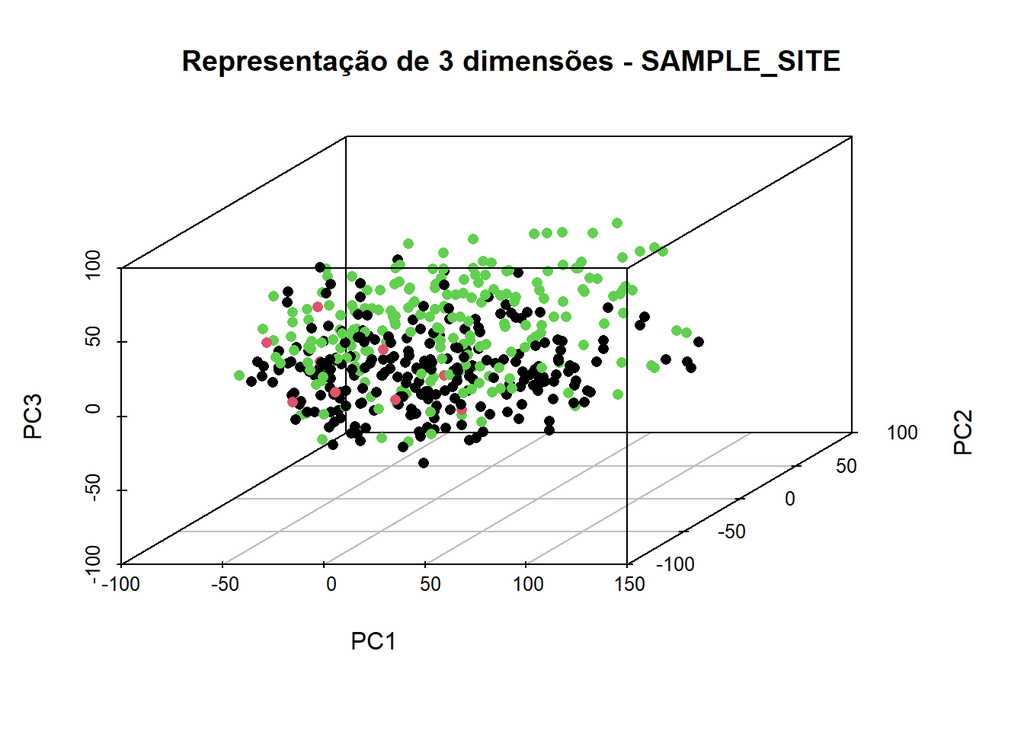

```r
# Plotegem de um gréfico com 3 dimensões
pca_data <- pca_result$x[, 1:3]
scatterplot3d(pca_data, color = as.integer(merged_df$SAMPLE_SITE), pch = 16,
              xlab = "PC1", ylab = "PC2", zlab = "PC3", main = "Representação de 3 dimensões - SAMPLE_SITE")
```

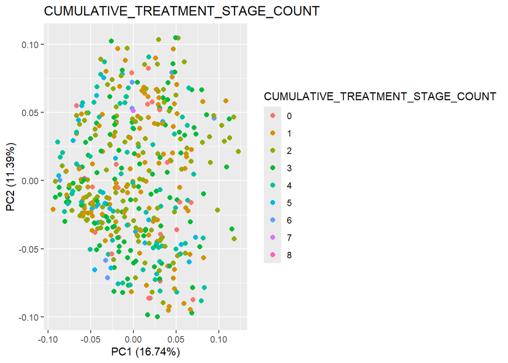

```r
# "CUMULATIVE_TREATMENT_STAGE_COUNT"
autoplot(pca_result, data = as.data.frame(merged_df), colour = "CUMULATIVE_TREATMENT_STAGE_COUNT", size = 2, main = "CUMULATIVE_TREATMENT_STAGE_COUNT")
```